# PixelMonitoring_polycrystalsMgO_Sept2026

**Laue Patterns digital processing to get single pixel or roi-related counters value over a dataset of images**

**pixel intensity monitoring**

**useful visualize grains in 2D Map (amesh dmesh scan)**

**no laue pattern indexing / refinement**

Author: J.-S. Micha

Last Revision: sept 2026

tested with python3.12 ubuntu 24.04 jupyter-slurm

**Objectives**

- Load and get pixel intensities on single pixel intensity or from ROIs statistics (pixel max intensity, position of max, postion of center of mass, position of gaussian fitting peak position)
- Visualize corresponding 2D or 1D scalar profile (intensity, spot position, etc)
- For 2D map (mesh scan): compilation of several map allows spatial determination of scattering region (grain, crystal, fluorescing material). It can be used to provide set of Laue spots very likely to belong to the same grain (useful for indexing routine)

some ways to obtain pixel intensity info in a set of images and at different given roi locations

# SET & check environment

```python
JUPYTER_LAB = True # False for jupyter hub or notebook

# at ESRF during experiment and 90 days after at /data/visitor
# OR for a long term porject at /data/projects
DATA_AT_ESRF_NICE=True   # False

# data can be /data/visitor or /data/projects  and  anywhere on linux ESRF machine or linux personnal laptop
ON_LINUX = True  # False

# ideally hdf5 files and data must be organized by subfolders as BLISS does
HDF5_LOGFILE_EXISTS = True  # False
```

# IMPORT packages

```python
# Matplotlib backend selection (JupyterLab vs. JupyterHub)
if not JUPYTER_LAB: # For JupyterHub
    %matplotlib notebook
else: # For JupyterLab
    %matplotlib widget

# Standard library imports
import os
import time
import copy
import itertools
import glob
from pathlib import Path

# Numerical and data handling
import numpy as np
import pandas as pd
import h5py

# Plotting and widgets
import matplotlib.pyplot as plt
import matplotlib
import ipywidgets as widgets
from ipywidgets import (
    FloatProgress, IntSlider, Button, HBox, VBox,
    Output, FloatRangeSlider, interact, interactive,
    fixed, interact_manual
)
from IPython.display import display
import fabio

# LaueTools imports
import LaueTools
import LaueTools.GUI.mosaic as MOS
import LaueTools.generaltools as GT
import LaueTools.IOimagefile as IOimage
import LaueTools.imageprocessing as Improc
import LaueTools.dict_LaueTools as DictLT
import LaueTools.IOLaueTools as IOLT
import LaueTools.readmccd as RMCCD
import LaueTools.blissdatafolderstructure as bf
import LaueTools.logfile_reader as iohdf5
import LaueTools.blissscan as bscan

# Print LaueTools paths
print('LaueTools location:', LaueTools.__file__)
print('LaueTools path:', LaueTools.__path__)

from LaueTools.imagescollector import (
    collectpixelvalue_singlefile,
    collectroissum_singlefile,
    collectroisptp_singlefile,
    collectroiarray_singlefile,
    collectroismax_singlefile,
    collectroisXYmax_singlefile,
    collectroisXYcenterofmass_singlefile,
    collectroisfitpeak_singlefile
)
```

```
loading lauetools_config.json in  <inhouse path>
No user materials.yaml found. Using default materials.yaml
loading readmccd.py
-- WARNING: Missing library libtiff, Please install: pylibtiff if you need open some tiff images. However, Fabio or PIL can do the job!
-- warning. BLISS control software is missing ? (normal if you are not at the beamline)
LaueTools location: <inhouse path>
LaueTools path: ['<inhouse path>']
```

```python
from tqdm import tqdm, tqdm_notebook
import itertools

import multiprocessing
from multiprocessing import active_children, cpu_count
print(f'{multiprocessing.cpu_count()} cpu(s) are available!\n')
```

```
64 cpu(s) are available!
```

# SET user-defined `ExperimentFolder`

parent folder of all raw data ot the experiment. For data at ESRF during and after experiment, the path should contain 'RAW_DATA'

```python
expId = '<proposal>'  # <user> MgO
```

## et al Mgo MgFe2O4

```python
if expId == '<proposal>':  #
    print(expId)

    CCDLabel = 'EIGER_4MCdTe'  # default sCMOS  = quad  (4M)  or 'sCMOS_4M'  binned 3x3 36M IMAGESTAR

    DATA_AT_ESRF_NICE = True
    HDF5_LOGFILE_EXISTS = True

    #ExperimentFolder = bf.getExperimentFolder(expId, data_at_esrf=DATA_AT_ESRF_NICE, expDate='<date>')
    ExperimentFolder = '/data/visitor/<proposal>/bm32/<date>/RAW_DATA/'
    ExperimentFolder
```

```
<proposal>
```

```python
if expId == '<proposal>':  #
    print(expId)

    CCDLabel = 'EIGER_4MCdTe'  # default sCMOS  = quad  (4M)  or 'sCMOS_4M'  binned 3x3 36M IMAGESTAR

    DATA_AT_ESRF_NICE = True
    HDF5_LOGFILE_EXISTS = True

    ExperimentFolder = bf.getExperimentFolder(expId, data_at_esrf=DATA_AT_ESRF_NICE)
    ExperimentFolder
```

```python
if expId == '<proposal>':  #
    print(expId)

    CCDLabel = 'EIGER_4MCdTe'  # default sCMOS  = quad  (4M)  or 'sCMOS_4M'  binned 3x3 36M IMAGESTAR

    DATA_AT_ESRF_NICE = True
    HDF5_LOGFILE_EXISTS = True
    if DATA_AT_ESRF_NICE:

        nicefolder = 'visitor'
        #nicefolder = os.path.join('bm32','inhouse')

        #--------------------------------------------
        ExperimentFolder = os.path.join('/data',nicefolder, f'{expId}/bm32/')

        listdates = os.listdir(ExperimentFolder)
        print('possible dates',listdates)
        if len(listdates)>1:
            GT.printyellow(f'\nBe careful, there are several dates ... => {listdates}\n')

        # to uncomment two lines to precise the date if there are several ones
        # ExperimentFolder= bf.setExperimentFolder_with_date(ExperimentFolder, expDate='<date>')
        # ExperimentFolder = os.path.join(ExperimentFolder,'RAW_DATA')

        ExperimentFolder= bf.setExperimentFolder_with_date(ExperimentFolder)

        print('ExperimentFolder set to ', ExperimentFolder)
    else:
        ExperimentFolder = userdefined_datafolder

    if os.path.exists(ExperimentFolder):
        GT.printgreen(f'\n"ExperimentFolder" exists ! : \n{ExperimentFolder}')

    if DATA_AT_ESRF_NICE and 'RAW_DATA' not in ExperimentFolder:
        GT.printyellow(f'\n"ExperimentFolder" does not contain "RAW_DATA"! Are you sure?')
```

```python
if expId == '<proposal>':  #
    print(expId)

    CCDLabel = 'EIGER_4MCdTe'  # default sCMOS  = quad  (4M)  or 'sCMOS_4M'  binned 3x3 36M IMAGESTAR

    DATA_AT_ESRF_NICE = True
    HDF5_LOGFILE_EXISTS = True
    if DATA_AT_ESRF_NICE:

        nicefolder = 'visitor'
        nicefolder = os.path.join('bm32','inhouse')

        #--------------------------------------------
        ExperimentFolder = os.path.join('/data',nicefolder, f'{expId}/bm32/')

        listdates = os.listdir(ExperimentFolder)
        print('possible dates',listdates)
        if len(listdates)>1:
            GT.printyellow(f'\nBe careful, there are several dates ... => {listdates}\n')

        # to uncomment two lines to precise the date if there are several ones
        # ExperimentFolder= bf.setExperimentFolder_with_date(ExperimentFolder, expDate='<date>')
        # ExperimentFolder = os.path.join(ExperimentFolder,'RAW_DATA')

        ExperimentFolder= bf.setExperimentFolder_with_date(ExperimentFolder)

        print('ExperimentFolder set to ', ExperimentFolder)
    else:
        ExperimentFolder = userdefined_datafolder

    if os.path.exists(ExperimentFolder):
        GT.printgreen(f'\n"ExperimentFolder" exists ! : \n{ExperimentFolder}')

    if DATA_AT_ESRF_NICE and 'RAW_DATA' not in ExperimentFolder:
        GT.printyellow(f'\n"ExperimentFolder" does not contain "RAW_DATA"! Are you sure?')
```

```python
if expId == '<proposal>':  # test <user>
    print(expId)

    CCDLabel = 'EIGER_4MCdTe'  # default sCMOS  = quad  (4M)  or 'sCMOS_4M'  binned 3x3 36M IMAGESTAR

    DATA_AT_ESRF_NICE = True
    HDF5_LOGFILE_EXISTS = True
    if DATA_AT_ESRF_NICE:

        nicefolder = 'visitor'
        #nicefolder = os.path.join('projects','mapgrainxl')

        #--------------------------------------------
        ExperimentFolder = os.path.join('/data',nicefolder, f'{expId}/bm32/')

        listdates = os.listdir(ExperimentFolder)
        print('possible dates',listdates)
        if len(listdates)>1:
            GT.printyellow(f'\nBe careful, there are several dates ... => {listdates}\n')

        # to uncomment two lines to precise the date if there are several ones
        # ExperimentFolder= bf.setExperimentFolder_with_date(ExperimentFolder, expDate='<date>')
        # ExperimentFolder = os.path.join(ExperimentFolder,'RAW_DATA')

        ExperimentFolder= bf.setExperimentFolder_with_date(ExperimentFolder)

        print('ExperimentFolder set to ', ExperimentFolder)
    else:
        ExperimentFolder = userdefined_datafolder

    if os.path.exists(ExperimentFolder):
        GT.printgreen(f'\n"ExperimentFolder" exists ! : \n{ExperimentFolder}')

    if DATA_AT_ESRF_NICE and 'RAW_DATA' not in ExperimentFolder:
        GT.printyellow(f'\n"ExperimentFolder" does not contain "RAW_DATA"! Are you sure?')
```

```python
if expId == '<proposal>':  # test <user>
    print(expId)

    CCDLabel = 'EIGER_4MCdTe'  # default sCMOS  = quad  (4M)  or 'sCMOS_4M'  binned 3x3 36M IMAGESTAR

    DATA_AT_ESRF_NICE = True
    HDF5_LOGFILE_EXISTS = True
    if DATA_AT_ESRF_NICE:

        nicefolder = 'visitor'
        #nicefolder = os.path.join('projects','mapgrainxl')

        #--------------------------------------------
        ExperimentFolder = os.path.join('/data',nicefolder, f'{expId}/bm32/')

        listdates = os.listdir(ExperimentFolder)
        print('possible dates',listdates)
        if len(listdates)>1:
            GT.printyellow(f'\nBe careful, there are several dates ... => {listdates}\n')

        # to uncomment two lines to precise the date if there are several ones
        # ExperimentFolder= bf.setExperimentFolder_with_date(ExperimentFolder, expDate='<date>')
        # ExperimentFolder = os.path.join(ExperimentFolder,'RAW_DATA')

        ExperimentFolder= bf.setExperimentFolder_with_date(ExperimentFolder)

        print('ExperimentFolder set to ', ExperimentFolder)
    else:
        ExperimentFolder = userdefined_datafolder

    if os.path.exists(ExperimentFolder):
        GT.printgreen(f'\n"ExperimentFolder" exists ! : \n{ExperimentFolder}')

    if DATA_AT_ESRF_NICE and 'RAW_DATA' not in ExperimentFolder:
        GT.printyellow(f'\n"ExperimentFolder" does not contain "RAW_DATA"! Are you sure?')
```

```python
if expId == '<proposal>':

    CCDLabel = 'sCMOS_4M'  # default sCMOS  = quad  (4M)  or 'sCMOS_4M'  binned 3x3 36M IMAGESTAR

    userdefined_datafolder =  '/my/folder/to/data'

    if DATA_AT_ESRF_NICE:

        nicefolder = 'visitor'
        #nicefolder = os.path.join('projects','mapgrainxl')

        #--------------------------------------------
        ExperimentFolder = os.path.join('/data',nicefolder, f'{expId}/bm32/')

        listdates = os.listdir(ExperimentFolder)
        print('possible dates',listdates)
        if len(listdates)>1:
            GT.printyellow(f'\nBe careful, there are several dates ... => {listdates}\n')

        # to uncomment two lines to precise the date if there are several ones
        # ExperimentFolder= bf.setExperimentFolder_with_date(ExperimentFolder, expDate='<date>')
        # ExperimentFolder = os.path.join(ExperimentFolder,'RAW_DATA')

        ExperimentFolder= bf.setExperimentFolder_with_date(ExperimentFolder)


        print('ExperimentFolder set to ', ExperimentFolder)
    else:
        ExperimentFolder = userdefined_datafolder

    if os.path.exists(ExperimentFolder):
        GT.printgreen(f'\n"ExperimentFolder" exists ! : \n{ExperimentFolder}')

    if DATA_AT_ESRF_NICE and 'RAW_DATA' not in ExperimentFolder:
        GT.printyellow(f'\n"ExperimentFolder" does not contain "RAW_DATA"! Are you sure?')
```

```python
if expId == '<proposal>':

    CCDLabel = 'sCMOS'  # default sCMOS  = quad  (4M)  or 'sCMOS_4M'  binned 3x3 36M IMAGESTAR

    userdefined_datafolder =  '/my/folder/to/data'

    if DATA_AT_ESRF_NICE:

        nicefolder = 'visitor'
        #nicefolder = os.path.join('projects','mapgrainxl')

        #--------------------------------------------
        ExperimentFolder = os.path.join('/data',nicefolder, f'{expId}/bm32/')

        listdates = os.listdir(ExperimentFolder)
        print('possible dates',listdates)
        if len(listdates)>1:
            GT.printyellow(f'\nBe careful, there are several dates ... => {listdates}\n')

        # to uncomment two lines to precise the date if there are several ones
        # ExperimentFolder= bf.setExperimentFolder_with_date(ExperimentFolder, expDate='<date>')
        # ExperimentFolder = os.path.join(ExperimentFolder,'RAW_DATA')

        ExperimentFolder= bf.setExperimentFolder_with_date(ExperimentFolder)


        print('ExperimentFolder set to ', ExperimentFolder)
    else:
        ExperimentFolder = userdefined_datafolder

    if os.path.exists(ExperimentFolder):
        GT.printgreen(f'\n"ExperimentFolder" exists ! : \n{ExperimentFolder}')

    if DATA_AT_ESRF_NICE and 'RAW_DATA' not in ExperimentFolder:
        GT.printyellow(f'\n"ExperimentFolder" does not contain "RAW_DATA"! Are you sure?')
```

# Browse data folders or hdf5 file, select a scan, and build rapidly scan parameter dictionnary `d`.

`d` to be used in next section

## [OPTIONS] list of folders and files by OS

```python
#ExperimentFolder = bf.getExperimentFolder(expId, data_at_esrf=DATA_AT_ESRF_NICE)
print('"ExperimentFolder" is set to:\n',ExperimentFolder)
```

```
"ExperimentFolder" is set to:
 /data/visitor/<proposal>/bm32/<date>/RAW_DATA/
```

```python
 bf.ls_folder(ExperimentFolder)
```

```
['<sample>_ZONE2',
 '<sample>_LARGE_FLUO_MAP',
 'align',
 '<sample>_ZONE3',
 '<sample>_RT_fishing',
 'PROCESSED_DATA',
 '<sample>',
 '<sample>',
 '<sample>',
 'fishing_p9_z3']
```

```python
bf.tree(ExperimentFolder,0)
```

```
├── align
├── fishing_p9_z3
├── <sample>
├── <sample>
├── <sample>_LARGE_FLUO_MAP
├── <sample>_ZONE2...
├── <sample>_RT_fishing
├── PROCESSED_DATA
└── <sample>
```

```python
bf.tree(Path(ExperimentFolder)/'<sample>',0, truncatesize=15)
```

```
├── <sample>_a_la_recherche_p7_1200
├── <sample>_align_p71250...
├── <sample>_align_up_to1000...
├── <sample>_final_align_p7_1000...
├── <sample>_map_2D_p7_MgO_Fe_1000...
├── <sample>_montee_500
├── <sample>_p3_fishing...
├── <sample>_p5_fishing
├── <sample>_p6_calib_MgO_1000...
├── <sample>_p7_1250_opti_before_heat
├── <sample>_search_p6_1300...
├── <sample>_Test_HT_1609
├── <sample>_test_roi_1000...
└── <dataset>
```

## read the hdf5 logfile:

```python
# use the master (uppest level) h5 file
pathHDF5, HDF5_LOGFILE_EXISTS = bf.findmasterh5file(ExperimentFolder)
print('master hdf5 file    :', pathHDF5, HDF5_LOGFILE_EXISTS)

# or use a lower level h5 file
subfolder ='<sample>'
pathHDF5_subfile,  HDF5_LOGFILE_EXISTS= bf.findmasterh5file(os.path.join(ExperimentFolder,subfolder))
print('local hdf5 file     :', pathHDF5_subfile,  HDF5_LOGFILE_EXISTS)
```

```
master hdf5 file    : /data/visitor/<proposal>/bm32/<date>/RAW_DATA/<sample> True
local hdf5 file     : /data/visitor/<proposal>/bm32/<date>/RAW_DATA/<sample>/<dataset> True
```

```python
#logfile = iohdf5.H5file(pathHDF5, CCDLabel)
logfile = iohdf5.H5file(pathHDF5_subfile, CCDLabel)
print('selected logfile .h5 :',logfile.path)
```

```
selected logfile .h5 : /data/visitor/<proposal>/bm32/<date>/RAW_DATA/<sample>/<dataset>
```

```python
#logfile.getscans(node_substrings=['map2D'],verbose=1)
logfile.getscans(verbose=1, node_substrings=['p7','800'], substrings_logic='AND')
```

```
number scans found : 17
number saved count commands found:  0
```

```python
logfile.dfallscans
```

|  | logfile_scanindex | start_time | duration_hours | end_time | sample_dataset_scanindex | fullcommand | scanindex | scantype | motors | localhdf5file | imagefolder | endreason | samplename |
| --- | --- | --- | --- | --- | --- | --- | --- | --- | --- | --- | --- | --- | --- |
| 0 | 0 | 2026-09-17 10:52:31 | 0.01 | 2026-09-17 10:53:04 | _final_align_p7_800_1 | ascan zech -0.49598 -0.19598 25 0.5 | 1 | ascan | zech | /data/visitor//bm32//RAW_DATA/ | /data/visitor//bm32//RAW_DATA/ | SUCCESS | b'' |
| 1 | 1 | 2026-09-17 10:54:22 | 0.01 | 2026-09-17 10:54:54 | _final_align_p7_800_2 | ascan xech 0.87820 1.17820 25 0.5 | 2 | ascan | xech | /data/visitor//bm32//RAW_DATA/ | /data/visitor//bm32//RAW_DATA/ | SUCCESS | b'' |
| 2 | 2 | 2026-09-17 10:55:03 | 0.01 | 2026-09-17 10:55:34 | _final_align_p7_800_3 | ascan zech -0.48186 -0.18186 25 0.5 | 3 | ascan | zech | /data/visitor//bm32//RAW_DATA/ | /data/visitor//bm32//RAW_DATA/ | SUCCESS | b'' |
| 3 | 3 | 2026-09-17 10:56:10 | 0.80 | 2026-09-17 11:44:19 | _1 | amesh yech -6.43556 -6.28556 50 xech 0.94557 1... | 1 | amesh | xech yech | /data/visitor//bm32//RAW_DATA/ | /data/visitor//bm32//RAW_DATA/ | SUCCESS | b'' |
| 4 | 4 | 2026-09-18 00:22:42 | 0.01 | 2026-09-18 00:23:12 | _align_p7_down_to_800_1 | ascan zech -0.33786 -0.03786 25 0.5 | 1 | ascan | zech | /data/visitor//bm32//RAW_DATA/ | /data/visitor//bm32//RAW_DATA/ | SUCCESS | b'' |
| 5 | 5 | 2026-09-18 00:23:14 | 0.01 | 2026-09-18 00:23:45 | _align_p7_down_to_800_2 | ascan xech 0.85696 1.15696 25 0.5 | 2 | ascan | xech | /data/visitor//bm32//RAW_DATA/ | /data/visitor//bm32//RAW_DATA/ | SUCCESS | b'' |
| 6 | 6 | 2026-09-18 00:23:47 | 0.01 | 2026-09-18 00:24:18 | _align_p7_down_to_800_3 | a2scan xech 0.95824 1.05824 yech -6.44711 -6.3... | 3 | a2scan | xech yech | /data/visitor//bm32//RAW_DATA/ | /data/visitor//bm32//RAW_DATA/ | SUCCESS | b'' |
| 7 | 7 | 2026-09-18 00:24:21 | 0.01 | 2026-09-18 00:24:52 | _align_p7_down_to_800_4 | a2scan xech 0.95164 1.05164 yech -6.35371 -6.4... | 4 | a2scan | xech yech | /data/visitor//bm32//RAW_DATA/ | /data/visitor//bm32//RAW_DATA/ | SUCCESS | b'' |
| 8 | 8 | 2026-09-18 00:24:54 | 0.01 | 2026-09-18 00:25:24 | _align_p7_down_to_800_5 | ascan zech -0.41894 -0.11894 25 0.5 | 5 | ascan | zech | /data/visitor//bm32//RAW_DATA/ | /data/visitor//bm32//RAW_DATA/ | SUCCESS | b'' |
| 9 | 9 | 2026-09-18 00:25:26 | 0.01 | 2026-09-18 00:25:56 | _align_p7_down_to_800_6 | ascan xech 0.84984 1.14984 25 0.5 | 6 | ascan | xech | /data/visitor//bm32//RAW_DATA/ | /data/visitor//bm32//RAW_DATA/ | SUCCESS | b'' |
| 10 | 10 | 2026-09-18 00:25:59 | 0.01 | 2026-09-18 00:26:30 | _align_p7_down_to_800_7 | a2scan xech 0.95255 1.05255 yech -6.45191 -6.3... | 7 | a2scan | xech yech | /data/visitor//bm32//RAW_DATA/ | /data/visitor//bm32//RAW_DATA/ | SUCCESS | b'' |
| 11 | 11 | 2026-09-18 00:26:32 | 0.01 | 2026-09-18 00:27:04 | _align_p7_down_to_800_8 | a2scan xech 0.95420 1.05420 yech -6.35026 -6.4... | 8 | a2scan | xech yech | /data/visitor//bm32//RAW_DATA/ | /data/visitor//bm32//RAW_DATA/ | SUCCESS | b'' |
| 12 | 12 | 2026-09-18 00:27:06 | 0.01 | 2026-09-18 00:27:36 | _align_p7_down_to_800_9 | ascan zech -0.43024 -0.13024 25 0.5 | 9 | ascan | zech | /data/visitor//bm32//RAW_DATA/ | /data/visitor//bm32//RAW_DATA/ | SUCCESS | b'' |
| 13 | 13 | 2026-09-18 00:27:38 | 0.01 | 2026-09-18 00:28:08 | _align_p7_down_to_800_10 | ascan xech 0.85971 1.15971 25 0.5 | 10 | ascan | xech | /data/visitor//bm32//RAW_DATA/ | /data/visitor//bm32//RAW_DATA/ | SUCCESS | b'' |
| 14 | 14 | 2026-09-18 00:28:10 | 0.01 | 2026-09-18 00:28:41 | _align_p7_down_to_800_11 | a2scan xech 0.96010 1.06010 yech -6.45577 -6.3... | 11 | a2scan | xech yech | /data/visitor//bm32//RAW_DATA/ | /data/visitor//bm32//RAW_DATA/ | SUCCESS | b'' |
| 15 | 15 | 2026-09-18 00:28:43 | 0.01 | 2026-09-18 00:29:14 | _align_p7_down_to_800_12 | a2scan xech 0.95250 1.05250 yech -6.36337 -6.4... | 12 | a2scan | xech yech | /data/visitor//bm32//RAW_DATA/ | /data/visitor//bm32//RAW_DATA/ | SUCCESS | b'' |
| 16 | 16 | 2026-09-18 00:29:20 | 0.77 | 2026-09-18 01:15:25 | _map_2D_p7_MgO_Fe_down_800_1 | amesh yech -6.48798 -6.33798 50 xech 0.92711 1... | 1 | amesh | xech yech | /data/visitor//bm32//RAW_DATA/ | /data/visitor//bm32//RAW_DATA/ | SUCCESS | b'' |

```python
d = logfile.build_dict_scan(3)
```

```
scan dictionary created for key 3 :)
scan 3 built and stored in logfile.selectedscans
```

```python
d
```

```
{'scantype': 'map',
 'start_time': Timestamp('2026-09-17 10:56:10'),
 'end_time': Timestamp('2026-09-17 11:44:19'),
 'sample_dataset_scanindex': '<dataset>_1',
 'fullcommand': 'amesh yech -6.43556 -6.28556 50 xech 0.94557 1.09557 50 0.5',
 'scanindex': '1',
 'motors': 'xech yech',
 'localhdf5file': '/data/visitor/<proposal>/bm32/<date>/RAW_DATA/<sample>/<dataset>/<dataset>.h5',
 'imagefolder': '/data/visitor/<proposal>/bm32/<date>/RAW_DATA/<sample>/<dataset>/scan0001',
 'endreason': 'SUCCESS',
 'samplename': b'<sample>',
 'folder': '/data/visitor/<proposal>/bm32/<date>/RAW_DATA/<sample>/<dataset>/scan0001',
 'nodeinhdf5file': '<sample>/<dataset>/1.1',
 'prefix': 'eiger4m_',
 'suffix': 'h5',
 'listindices': array([   0,    1,    2, ..., 2598, 2599, 2600], shape=(2601,)),
 'nbimagesperline': 51,
 'mapdimensions': (51, 51),
 'peaklistfile': None,
 'fastaxis': 'yech',
 'slowaxis': 'xech',
 'collector': 'pixelval',
 'CCDLabel': 'EIGER_4MCdTe'}
```

```python
dfmeshscans = None
if HDF5_LOGFILE_EXISTS:
    # ALL MESH SCANS  (2D Map)
    pd.set_option('max_colwidth', 200)
    dfmeshscans = dfallscans[dfallscans['scantype']=='amesh'][['sample_dataset_scanindex','fullcommand', 'imagefolder', 'motors']]
dfmeshscans
```

```python
# to see a specific item  use ** iloc **  (absolute index in dfmeshscans)
item_idx = 2

if item_idx<len(dfmeshscans):
    print(dfmeshscans.iloc[item_idx])
else:
    GT.printyellow('this item index does not exist')
```

```python
# ALL ZF SCANS (DAXM Wire scans) or Diamond scan (thf)
if HDF5_LOGFILE_EXISTS:

    motorname = 'zf'
    print('location of images for scans of %s'%motorname)
    dfallscans.loc[dfallscans['motors'] == motorname]['imagefolder']

dfallscans
```

```python
dfzfscans = None
if HDF5_LOGFILE_EXISTS:

    pd.set_option('max_colwidth', 200)
    dfzfscans = dfallscans[dfallscans['motors']=='zf'][['sample_dataset_scanindex','fullcommand', 'imagefolder', 'motors']]
dfzfscans
```

```python
# narrow the search of specific folder

selected_scans = None

#df = dfzfscans
df = dfallscans

if expId == '<proposal>':
    str_in_dataset = 'A45'  #'TRUE_COM' #'A45'
    motor_in_motors =  'zf' #'thf'
if expId == '<proposal>':
    str_in_dataset = 'TRUE_COM'
    motor_in_motors =  'thf'

cond_dataset  = df['sample_dataset_scanindex'].str.contains(str_in_dataset)
cond_motor  = df['fullcommand'].str.contains(motor_in_motors)

cond = cond_dataset & cond_motor

if HDF5_LOGFILE_EXISTS:
    selected_scans=df[cond][
                        ['sample_dataset_scanindex','fullcommand', 'imagefolder', 'motors']]

selected_scans
```

```python
if expId == '<proposal>':
    queryimage = os.path.join(d290['folder'],'img_0400.tif')
    print('image', queryimage)

    blisscommand, imagedate, dfallscans_index = IOimage.fromscmosdate2blisscommand(queryimage, dfallscans)
    print('blisscommand',blisscommand)
    print('imagedate',imagedate)
    print('dfallscans_index', dfallscans_index)
```

#### Example 1: Select the scan collecting images at querydate

```python
import datetime

querydate = datetime.datetime(2024,6,18,23,33,30)  # y m d  h min sec
print('querydate',querydate)

mask = (dfallscans['end_time'] > querydate.isoformat()) & (dfallscans['start_time'] <= querydate.isoformat())
dfallscansgooddate = dfallscans.loc[mask]

print(dfallscansgooddate.fullcommand.values)
dfallscansgooddate
```

#### Example 2: Select the scan collecting images at during the period

```python
# period is defined by  [querydate-timespan, querydate+timespan]
querydate = datetime.datetime(2024,6,18,23,33,30)  # y m d  h min sec
timespan = 60 # min

minidate = datetime.datetime.fromtimestamp(querydate.timestamp()-timespan*60)
maxidate = datetime.datetime.fromtimestamp(querydate.timestamp()+timespan*60)
mask2 = (dfallscans['end_time'] < maxidate.isoformat()) & (dfallscans['start_time'] > minidate.isoformat() )
dfallscansgoodperiod = dfallscans.loc[mask2]

#print(dfallscansgoodperiod.fullcommand.values)
print(dfallscansgoodperiod[['fullcommand', 'imagefolder', 'start_time']])
dfallscansgoodperiod
```

```python
# get images_subfolder from dataframe index and fullpath image folder
dfallscans_idx = 290
dataframescanslist = dfallscans  # whatever ... dfzfscans, dfallscans

#*********************************
#to see a specific item property  use ** loc **
fullpath_imagefolder = dataframescanslist.loc[dfallscans_idx]['imagefolder']

images_subfolder = bf.setimages_subfolder(fullpath_imagefolder, rootfolder='RAW_DATA')
print('for item #%d'%dfallscans_idx)
print('images_subfolder is (to be copied afterwards if needed):')
print(images_subfolder)
```

```python
# ***********FINAL CHOICE **************
if expId == '<proposal>':
    d=d15
    d=d23
    d=d0

if expId == '<proposal>':
    d=d59
    d=d461
    d=d465
    d=d5
if expId == '<proposal>':
    d=d25
    d=d26
    d=d27
    #d=d30
    d=d33
if expId == '<proposal>':

    d= d9  #   <sample> map
    d =d10  #  <sample> large map

    d =d12  #  FE large map
if expId == '<proposal>':
    d= d48  # daxm   650 micron   daxm   expp 1 sec
    d= d89  # daxm   650 micron   daxm  expo 5 sec


if expId == '<proposal>':
    d= d289  # Ge
    #
    d= d290   # alumina
```

```python
s = bscan.BlissScan(d)
#print('s',s)
```

```python
s.possible_workflows()
```

```python
s.launch_workflow('mosaic')
```

# DEFINE and CHOOSE Counters (ROIs) location: from peaksearch, evenly spaced (gridroi) or randomly chosen

## [OPTION 1] peaksearch on single image (No peakshape FIT): integer coordinates

### compute `roiposition` from peaksearch

```python
imageindex = 1300

Data_for_localMaxima = 'auto_background'


IntensityThreshold = 200  # 200 for Ge wafer

#--------------end of user input--------------------
ADD_ROIS_FOR_DAXM_BACKGROUND= False
if isinstance(d['folder'],list):
    folder = d['folder'][0]
else:
    folder = d['folder']
intensities = None
roiposition = None
r = RMCCD.PeakSearch(os.path.join(folder,f"{d['prefix']}%04d.{d['suffix']}"%imageindex),
                    CCDLabel=d['CCDLabel'],
                    IntensityThreshold=IntensityThreshold,
                    Data_for_localMaxima=Data_for_localMaxima,
                    fit_peaks_gaussian=0,
                    local_maxima_search_method=0,
                    boxsize=5,
                    Saturation_value= 6000000,
                    PeakSizeRange=(.2, 1),
                    maxPixelDistanceRejection=5,
                    NumberMaxofFits=20000,
                    verbose=0)  # high value to for 1000s spots
if r is None:
    GT.printyellow('Nothing found. Try to change "IntensityThreshold" neither too small nor too large (first: 1000-5000 ?)')
if r is not None:
    roiposition = r[-1]
    nb_peaks_found = len(roiposition)
    if nb_peaks_found>0:
        GT.printgreen(f'nb peaks {len(roiposition)}')
    intensities = r[0][:,2]

    #hottest pixel:
    hottestspot_index = np.argsort(r[0][:,2])[::-1][0]
    print('hottest pixel : [X, Y, intensity above background] is:\n', r[0][hottestspot_index][:3])
```

```
nb peaks 1342
hottest pixel : [X, Y, intensity above background] is:
 [ 1138.   1151.  51811.5]
```

```python
MASK_REGIONS = False
if MASK_REGIONS:
    XY= roiposition
    #Xtest, Ytest=[2324,3521]
    Xtest, Ytest=[2226,3670]
    xcond =np.fabs(XY[:,0]-Xtest)<5
    ycond =np.fabs(XY[:,1]-Ytest)<10
    cond = np.logical_and(xcond,ycond)
    np.where(cond)
```

```python
SORTED_BY_INTENSITY = True
if SORTED_BY_INTENSITY:# sorted by decreasing intensity
    sortedindices = np.argsort(r[0][:,2])[::-1]
    speaks = r[0][sortedindices]
    roiposition = speaks[:,:2]
    intensities = r[0][:,2][sortedindices]
    print('   X, \t\t\tY, \t\tIntensity above BackGround')
    print(np.column_stack((roiposition, intensities)))
```

```
   X, 			Y, 		Intensity above BackGround
[[ 1138.                1151.               51811.5             ]
 [  607.                1558.               46110.69921875      ]
 [ 1401.                1955.               39822.              ]
 ...
 [ 1359.                1749.                 200.19998168945312]
 [ 1718.                1841.                 200.09999084472656]
 [  451.                2149.                 200.09999084472656]]
```

### GUI: laue pattern image browser + `roiposition` from peaksearch

```python
fullpath = os.path.join(folder,f"{d['prefix']}%04d.{d['suffix']}"%imageindex)
os.path.exists(fullpath)
```

```
True
```

```python
from ipywidgets import interact, interactive, fixed, interact_manual
```

[figure not shown]

```
[interactive widget (ipywidgets)]
```

```
[interactive widget (ipywidgets)]
```

```
[interactive widget (ipywidgets)]
```

```python
import os
import fabio
import numpy as np
import matplotlib.pyplot as plt
from ipywidgets import interactive

# Assume `d` is a dictionary containing:
# - 'prefix': Prefix for image filenames
# - 'suffix': Suffix for image filenames
# - 'mapdimensions': Tuple (nslow, nfast) representing rows and columns
# - 'listindices': List of valid indices (if needed)
# - 'folder': Path to the folder containing images

# Extract dimensions
nslow, nfast = d['mapdimensions']  # to be cchecked for the convention
col0 = nfast//2
row0 = nslow//2
imageindex0 = col0*nfast+row0

# Initialize figure and axis
figp, axp = plt.subplots()
plt.show(block=False)  # Show the figure in non-blocking mode

# Variable to store the clicked pixel
clicked_pixel = None

# Output widget for printing clicked coordinates
output = Output()
display(output)

# Function to handle click events
# Function to handle click events
def on_click(event):
    global clicked_pixel
    if event.inaxes == axp:  # Ensure the click is within the image axes
        x, y = float(event.xdata), float(event.ydata)
        clicked_pixel = (int(x), int(y))
        with output:
            output.clear_output()
            print(f"Clicked pixel: (x={x:.1f}, y={y:.1f})")

# Connect the click event to the figure
figp.canvas.mpl_connect('button_press_event', on_click)
fullpath = os.path.join(folder, f"{d['prefix']}%04d.{d['suffix']}" % imageindex0)
with fabio.open(fullpath) as img:
        imgdata = img.data

axp.imshow(imgdata, vmin = 0, vmax =2000)#, cmap=plt.cm.OrRd)

# Function to plot the image based on rowindex and colindex
def plotimage(rowindex=0, colindex=0, vmin=1000, vmax=2000, show_rois=False):
    global clicked_pixel
    # Calculate imageindex
    imageindex = rowindex * nfast + colindex

    # Construct the full path
    fullpath = os.path.join(folder, f"{d['prefix']}%04d.{d['suffix']}" % imageindex)

    # Check if the file exists
    if not os.path.exists(fullpath):
        print(f"\n'fullpath' does not exist!:\n{fullpath}")
        return

    # Open the image and get data
    with fabio.open(fullpath) as img:
        imgdata = img.data


    print('imageindex', imageindex)

    # Clear the axis and set limits
    ymin, ymax = axp.get_ylim()
    xmin, xmax = axp.get_xlim()
    axp.clear()
    axp.set_xlim(xmin, xmax)
    axp.set_ylim(ymin, ymax)

    # Adjust limits if needed
    ymin, ymax, xmin, xmax = int(ymin), int(ymax), int(xmin), int(xmax)
    if ymin > ymax:
        ymin, ymax = ymax, ymin

    # Set the title
    if 'RAW_DATA' in fullpath:
        figtitle = fullpath.rsplit('/RAW_DATA/')[1]
    else:
        figtitle = fullpath
    figp.suptitle(f"{ExperimentFolder}\n{figtitle}")

    # Display the image
    axp.imshow(imgdata, vmin=vmin, vmax=vmax, cmap=plt.cm.BuGn)

    # Show ROIs if enabled
    if show_rois:
        offsetXYtoplot = (1, 1)
        for pt in roiposition:
            axp.scatter(pt[0] - offsetXYtoplot[0], pt[1] - offsetXYtoplot[1], marker='+', color='r')

    plt.draw()  # Redraw the figure

# Create a button to print the clicked pixel
button = Button(description="Save Clicked Pixel")

def on_button_click(b):
    global clicked_pixel
    with output:
        output.clear_output()
        if clicked_pixel is not None:
            print(f"Saved clicked pixel: {clicked_pixel}")
        else:
            print("No pixel clicked yet.")

button.on_click(on_button_click)

# Display the button and output
display(button)

# Create interactive sliders
interactive(
    plotimage,
    colindex=IntSlider(min=0, max=nfast-1, step=1, value=col0, continuous_update=False, tooltip=f"along {d['fastaxis']}"),
    rowindex=IntSlider(min=0, max=nslow-1, step=1, value=row0, continuous_update=False, tooltip=f"along {d['slowaxis']}"),
    vmin=(0, 50),
    vmax=(100, 5000),
    show_rois=[False, True]
)
```

```python
print('clicked_pixel', clicked_pixel)
d['roicenter']=clicked_pixel  # useful for section  to process mosaic  plot
```

```
clicked_pixel (994, 866)
```

```python
# [OPTION] [HELPER] find the position of a roi given XY pixels coordinates
if 0:
    XY= roiposition
    #Xtest, Ytest=[2324,3521]
    Xtest, Ytest=[1156,1825]
    Xtest, Ytest=[918,1730]

    xtolerance, ytolerance = 5, 10

    #--------------------------------------
    xcond =np.fabs(XY[:,0]-Xtest)<xtolerance
    ycond =np.fabs(XY[:,1]-Ytest)<ytolerance
    cond = np.logical_and(xcond,ycond)
    potential_index = np.where(cond)[0]

    potential_index, XY[potential_index]
```

#### [OPTION] Modify ROIs list

```python
MANUAL_MODIFY= False
if MANUAL_MODIFY:# manual modification of roi (overwrite)
    roiposition[-1]=np.array([744,700])
#     roiposition[1]=np.array([1116,853])
#     roiposition[2]=np.array([424,1936])
```

```python
MANUAL_ADD= False

if MANUAL_ADD:
    roiposition= np.concatenate((np.array([[744,700],[900,958],[550,360]]),roiposition), axis=0)
    # you may need to add elements `intensities` array
    intensities= np.concatenate((np.array([1,1,1]),intensities), axis=0)
```

```python
print('total number of spots in list: ',len(roiposition))
np.set_printoptions(suppress=True,precision=3)
print('   X,      Y,      Intensity above BackGround')
print(np.column_stack((roiposition, intensities)))
np.set_printoptions(suppress=True,precision=7)
```

```
total number of spots in list:  1342
   X,      Y,      Intensity above BackGround
[[ 1138.     1151.    51811.5  ]
 [  607.     1558.    46110.699]
 [ 1401.     1955.    39822.   ]
 ...
 [ 1359.     1749.      200.2  ]
 [ 1718.     1841.      200.1  ]
 [  451.     2149.      200.1  ]]
```

#### build array of bckgposition

```python
if d['scantype']=='daxm' and ADD_ROIS_FOR_DAXM_BACKGROUND:

    bckgposition= np.zeros_like(roiposition)
    print(bckgposition.shape)
    nbgood = 0
    indexgood =  []
    for k, roixy in enumerate(roiposition):
        Ybckg=roixy[1]
        res =predictpixelforbackground(roixy,imgdata, halfsize=5)
        print(res)
        Xbckg,poordetection,incamera = res

        if incamera and not poordetection:
            print('*****>',[Xbckg, Ybckg])
            bckgposition[k]=[Xbckg, Ybckg]
            nbgood+=1
            indexgood.append(k)
```

```python
if d['scantype']=='daxm' and ADD_ROIS_FOR_DAXM_BACKGROUND:

    print('nb background pixel sensors found: %d  over %d rois in roiposition'%(nbgood, len(roiposition)))
    print('index of roi with bckg pixel sensor',indexgood)
    bckgposition
```

```python
if d['scantype']=='daxm' and ADD_ROIS_FOR_DAXM_BACKGROUND:
    len(bckgposition)
```

#### be careful when resetting `roiposition` to `roiposition`+`bckgposition`

```python
# TODO  collect intensity profile for bckgposition
if d['scantype']=='daxm' and ADD_ROIS_FOR_DAXM_BACKGROUND:

    roiposition = np.concatenate((roiposition, bckgposition),axis=0)
    print('Now `roiposition` should be twice longer ... and contains ROI locating at the baseline of each ROI')
    print(roiposition.shape)
    # forming fake intensities data for background pixel
    d['intensities'] = np.concatenate((d['intensities'],d['intensities']))
    print(d['intensities'].shape)
```

## [OPTION 2] Read peak positions in .fit file

```python
fitfile = '/data/visitor/<proposal>/bm32/<date>/RAW_DATA/<sample>/<dataset>/scan0001/dat_img_0000_LT_0_fitnb_1.fit'
```

```python
graindata = IOLT.readfile_fit(fitfile)[4]
XYgrain = graindata[:,7:9]
intensities_fitfile = graindata[:,1]

# sorting by increasing Y for DAXM
sortedYindices = np.argsort(XYgrain[:,1])
XYgrain= np.take(XYgrain,sortedYindices, axis=0)
XYgrain
```

## [OPTION 4] get roi position from a built regular array of rois

### set `gridroi` ROI position

```python
# quadbin1  :  maxnbpixels = 2000  # quad scmos binning 2X2  4M pixels
# imstarbin2 :  maxnbpixels = 3000    # scmos_9M binning hardware 2X2  9M pixels   gsense6060 imagestar165

# ROIs are in whole detector area
gridroi = GT.buildgridroi(spacing=100,maxnbpixels=2060)

# ROIs are in the half lower part of detector area
#gridroi = GT.buildgridroi_bottom(spacing=15,maxnbpixels=2060)
# set general parameter (which is filled  by peaksearch)
intensities_gridrois = None

gridroi, gridroi.shape
```

```
441
(21, 21, 2)
```

```
(array([[  50,   50],
        [  50,  150],
        [  50,  250],
        [  50,  350],
        [  50,  450],
        [  50,  550],
        [  50,  650],
        [  50,  750],
        [  50,  850],
        [  50,  950],
        [  50, 1050],
        [  50, 1150],
        [  50, 1250],
        [  50, 1350],
        [  50, 1450],
        [  50, 1550],
        [  50, 1650],
        [  50, 1750],
        [  50, 1850],
        [  50, 1950],
        [  50, 2050],
        [ 150,   50],
        [ 150,  150],
        [ 150,  250],
        [ 150,  350],
        [ 150,  450],
        [ 150,  550],
        [ 150,  650],
        [ 150,  750],
        [ 150,  850],
        [ 150,  950],
        [ 150, 1050],
        [ 150, 1150],
        [ 150, 1250],
        [ 150, 1350],
        [ 150, 1450],
        [ 150, 1550],
        [ 150, 1650],
        [ 150, 1750],
        [ 150, 1850],
```

[output cut: 387 more lines]

```
        [2050,  750],
        [2050,  850],
        [2050,  950],
        [2050, 1050],
        [2050, 1150],
        [2050, 1250],
        [2050, 1350],
        [2050, 1450],
        [2050, 1550],
        [2050, 1650],
        [2050, 1750],
        [2050, 1850],
        [2050, 1950],
        [2050, 2050]]),
 (441, 2))
```

### [OPTION] plot markers if needed

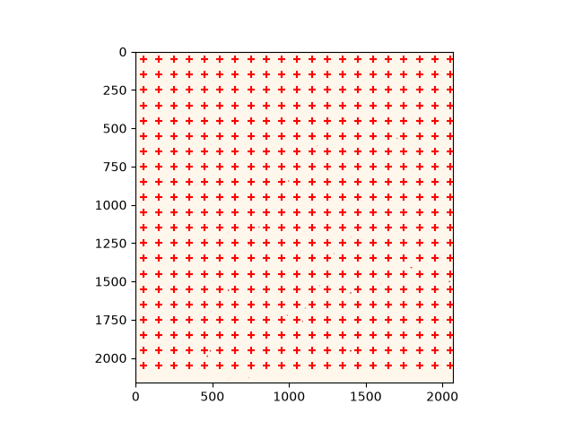

```python
nbrois_grid = gridroi.shape[0]
try:
    maximage = np.amax(imgdata)
except NameError:
    imgdata = 1000*np.ones((2200, 2200))

if nbrois_grid<1000:
    fig,ax = plt.subplots()

    if imgdata is None:
        imgdata = 1000*np.ones((2000,2000))
    #ax.imshow(np.log10(imgdata), vmin = 3, vmax = 3.5, cmap=plt.cm.inferno)
    ax.imshow(imgdata, vmin = 1000, vmax =6000, cmap=plt.cm.OrRd)
    for pt in gridroi:
        ax.scatter(pt[0],pt[1],marker='+',color='r')
        ax.set_title('')

    plt.show()
else:
    GT.printyellow(f'nb of rois in the grid ({nbrois_grid}) is too large to be reasonnably plot')
```

# SET centers of ROI: setting `d['peaklist']`

SET one flag to True to choose the ROIs center location origin

(part of roi positions can also be selected)

```python
USE_PEAKSEARCH_LIST = False  # True for DAXM  False for 2D Map  (could include first half of ROI center peak and second half of neighbouring peaks
USE_GRIDROI_LIST = True  # False for DAXM  True for 2D Map
USE_RANDOM_POSITION_LIST = False
USE_ROIPIXELS = False
USE_FITFILE_PEAKLIST = False

# -------------------------------------------
lflag = [USE_PEAKSEARCH_LIST,USE_GRIDROI_LIST,USE_RANDOM_POSITION_LIST,USE_ROIPIXELS,USE_FITFILE_PEAKLIST]

if sum(lflag)==0:
    GT.printyellow('One "USE_###" flag at least should be True')
elif sum(lflag)>1:
    GT.printred('Please set only one "USE_###" flag to True')
#-------------------------------------------
#read pixel positions of peaks from key 'peaklistfile'
if 0:
    if 'peaklist' not in d or d['peaklist'] is None:
        if d['peaklistfile'] is not None:# default
            iohdf5.getpeaklist(d)
        print(d['peaklist'])

        # use the variable gridroi
alreadyselected = 0
if USE_RANDOM_POSITION_LIST: # or input them: data = array of peaks position

    # RANDOM ROIS
    nbofrois = 300
    maxXYpixelvalue = 2000 # given by the dimension of the detector
    iohdf5.getpeaklist(d, data=np.random.randint(maxXYpixelvalue,size=(nbofrois,2)))
    alreadyselected += 1
if USE_GRIDROI_LIST:

    # regular spaced ROIS
    iohdf5.getpeaklist(d, data=gridroi)
    alreadyselected += 1
    intensities = None  # patch
if USE_PEAKSEARCH_LIST:
    # ROIS from peak peaksearch above
    iohdf5.getpeaklist(d, data=roiposition)
    alreadyselected += 1

if USE_ROIPIXELS:

    iohdf5.getpeaklist(d, data=roipixels)

if USE_FITFILE_PEAKLIST:

    iohdf5.getpeaklist(d, data=XYgrain)
    alreadyselected += 1
    d['intensities']=intensities_fitfile

if alreadyselected > 1:
    GT.printred(f'You must select a single type of list! Check there is only one True value at the top of the cell!')
if 0:#  ---
    iohdf5.sortpeaklist(d)
    print(d['peaklist'])

if 0:  # select the first number of rois
    selectnb=20
    d['peaklist']=d['peaklist'][:selectnb+1]

GT.printgreen(f"\nnb of rois : {len(d['peaklist'])}")
if len(d['peaklist'])>10: print('10 first current peaklist', d['peaklist'][:10])

if 1:  # reset manually some roi centers
    d['peaklist'][0]=[990,840]
    #d['peaklist'][1]=[582,840]

if intensities is not None:
    d['intensities']=intensities
    if ADD_ROIS_FOR_DAXM_BACKGROUND:
        d['intensities'] = np.concatenate((d['intensities'],d['intensities']))
    print('values of last peaksearch peaks intensities are in d["intensities"]')
```

```
key 'peaklist' is filled

nb of rois : 441
10 first current peaklist [[990 840]
 [ 50 150]
 [ 50 250]
 [ 50 350]
 [ 50 450]
 [ 50 550]
 [ 50 650]
 [ 50 750]
 [ 50 850]
 [ 50 950]]
```

## final dict for exp. parameters (folder and rois)

```python
# d
```

# COLLECT Mosaic Multiprocessing

each 2D small part around the same single pixel position `d['roicenter']`is taken over all images and rearranged to form form a mosaic of local 2D signal

```python
# rapid Manual entry
if d:
    #d['roicenter']=d['peaklist'][3500]
    d['roicenter']=[1410,1595]
    d['roicenter'] =  [980, 800]   # 1250C
    d['roicenter'] = clicked_pixel
```

```python
if __name__=='__main__':

    collector = 'mosaic'
    nbcpus= 64 # > 1 !!

    # for roimax or roiXYmax
    boxsize_X=25  # along pixel X
    boxsize_Y=25  # along pixel Y

    # images to be handled
    listindices = None#  None means take indices in d[['listindices']]
    nbcompletelines = None  #10  # None all lines when scan is completed

    #---------------------Multiprocessing-----------------------------------------------
    dictparam=d

    maxnbcpus = cpu_count()
    if nbcpus is None:
        nbcpus = maxnbcpus
    else:
        nbcpus = max(2,min(nbcpus,maxnbcpus))
    print('nbcpus', nbcpus)

    roicenter=dictparam.get('roicenter', None)
    prefix=dictparam.get('prefix', None)
    folder=dictparam.get('folder', None)
    CCDLabel=dictparam.get('CCDLabel', None)

    if roicenter is None:
        GT.printred(f"d['roicenter'] is not set to extract pixel intensities around it")
    else:
        xroi, yroi = d['roicenter']
        maxdimension = 2015
        if xroi-boxsize_X<0 or xroi+boxsize_X>maxdimension or yroi-boxsize_Y<0 or yroi+boxsize_Y>maxdimension:
            GT.printred(f"d['roicenter'] {d['roicenter']} is too close from detector frame border for the boxsize : {(boxsize_X, boxsize_Y)}")

    if listindices is None:
        listindices=dictparam['listindices']
        if nbcompletelines is not None:
            listindices=dictparam['listindices'][:dictparam['nbimagesperline']*nbcompletelines]
            print(dictparam['mapdimensions'][0],nbcompletelines)

            # warning  : reset d values !!
            d['mapdimensions']=(dictparam['mapdimensions'][0],nbcompletelines)
            d['listindices'] =listindices

    if not isinstance(folder, list):  # iteration over images on the same folder
        nbimages = len(listindices)
        listfolders = itertools.repeat(folder)

    else: # iteration over a list of folders
        print('Multiple folders screened')
        nbimages = len(folder)
        listfolders = folder
        listindices = itertools.repeat(dictparam['listindices'])

    #----------------------------------

    t00 = time.time()
    print(f'using {collector} as collector: {nbimages} images, {nbcpus} cpu(s)')

    args_mosaic = zip(listindices,
                   itertools.repeat(roicenter),
                   itertools.repeat(prefix),
                   listfolders,
                  itertools.repeat(boxsize_X),
                  itertools.repeat(boxsize_Y),
                   itertools.repeat(CCDLabel),
                   )

    #print('args_pixelvalue',[elem for elem in args_pixelvalue])

    with multiprocessing.Pool(nbcpus) as pool:

        allresults = pool.starmap(collectroiarray_singlefile,
                                      tqdm(args_mosaic, total=nbimages,
                                      desc='sum values progress bar:'), chunksize=1)

    allresults = np.array(allresults)

    elapsedtime=time.time()-t00
    print(f'total time is {elapsedtime:.3f} sec for {nbimages} images and {nbcpus} cpu(s)')

    children = active_children()
    print(f'Active children: {len(children)}')

    d['allresults']=allresults
    print('Results are in allresults or allresults key...\n\n!!! ----- Collection done ;-) ----!!')

print('allresults.shape = (nbimages x boxsize x boxsize)', allresults.shape)
```

```
nbcpus 40
using mosaic as collector: 2601 images, 40 cpu(s)
```

```
total time is 9.755 sec for 2601 images and 40 cpu(s)
Active children: 0
Results are in allresults or allresults key...

!!! ----- Collection done ;-) ----!!
allresults.shape = (nbimages x boxsize x boxsize) (2601, 51, 51)
```

## rearranging results for 2D mesh scan (map)

```python
# plot mosaic from 2D map
if d['scantype']=='map':
    # processing and rearranging collected ROIs imagelets
    dimfast, dimslow = d['mapdimensions']
    print('axis dimensions: dimslow, dimfast',dimslow, dimfast)
    mosaic = np.zeros((dimslow, dimfast, 2*boxsize_Y+1, 2*boxsize_X+1))
    print('mosaic.shape', mosaic.shape)
    dict_map_imageindex ={}

    print(d['listindices'])

    sm = mosaic.shape
    bigimage = np.zeros((sm[0]*sm[2],sm[1]*sm[3]))


    if dimfast > 0:
        for map_imageindex, absolute_imageindex in enumerate(d['listindices']):

            imap, jmap = map_imageindex // dimfast, map_imageindex % dimfast

            dict_map_imageindex[map_imageindex] = [absolute_imageindex,
                                                    map_imageindex,
                                                    imap, jmap]

            raw = allresults[map_imageindex,:,:]

            #datcrop = np.flipud(raw).T
            datcrop = raw

            mosaic[imap,jmap] = datcrop #datcrop.T #np.flipud(datcrop).T
            # for 2D map
            bigimage[imap*sm[2]:(imap+1)*sm[2], jmap*sm[3]:(jmap+1)*sm[3]] = np.flipud(datcrop)

    if 1:
        mosaictranspose = mosaic.transpose((0, 3, 1, 2))
        mosaicflat = mosaictranspose.reshape((dimfast * (2 * boxsize_X + 1), dimslow * (2 * boxsize_Y + 1)))

    print('mosaictranspose.shape',mosaictranspose.shape)
    print('mosaicflat.shape',mosaicflat.shape)
    print('pixel ', d['roicenter'])
    #dat_dims = (nb_lines * (2 * boxsize_Y + 1), nb_col * (2 * boxsize_col + 1))
```

```
axis dimensions: dimslow, dimfast 51 51
mosaic.shape (51, 51, 51, 51)
[   0    1    2 ... 2598 2599 2600]
mosaictranspose.shape (51, 51, 51, 51)
mosaicflat.shape (2601, 2601)
pixel  (994, 866)
```

## [OPTION] picking results and/or saving figure

```python
# results can be written in user-defined folder or in 'PROCESSED_DATA'
if not isinstance(folder, list):   # single folder
    #genfolder = folder
    genfolder = bf.createmirrorfolder(folder)
else:
    genfolder = os.path.join(os.path.split(ExperimentFolder)[0],'PROCESSED_DATA')

# in projects/mapgrainxl  there is no 'PROCESSED_DATA'
genfolder = folder

if os.path.isdir(genfolder):
    GT.printgreen(f'\nAnalysis results will be written is "genfolder":\n {genfolder}')
```

```python
# use genfolder to write output  results
import pickle

if 0: # SAVE
    dictresults=copy.copy(d)
    dictresults['allresults']=allresults
    dictresults['mosaic']=mosaic
    dictresults['bigimage']=bigimage
    with open(os.path.join(genfolder,'%s_roicenter_X_%d_Y_%d.pickle'%(collector,int(roicenter[0]),int(roicenter[1]))), 'wb') as f:
        pickle.dump(dictresults, f)

if 0: #LOAD
    if input('Are you sure to load a previous file and overwrite dictresults?') in ('y','yes','Y','YES','o','O'):

        folder = '/data/visitor/<proposal>/bm32/<date>/SiCnuit/SiCnuit_bulle2/scan0001'
        collector = 'fitpeakXY'
        #folder = d['folder']

        #with open(os.path.join(folder,'%s_20counters.pickle'%collector), 'rb') as f:
        with open(os.path.join(genfolder,'fitpeakXY_20counters'+'.pickle'), 'rb') as f:
            dictresults=pickle.load(f)

        d=dictresults
        allresults = d['allresults']
        mosaic = d['mosaic']
        bigimage = d['bigimage']
```

## [OPTION] visualisation of imagelet

```
25 25
data2D.shape (51, 51)
initial roi size (X, Y) 51 51
```

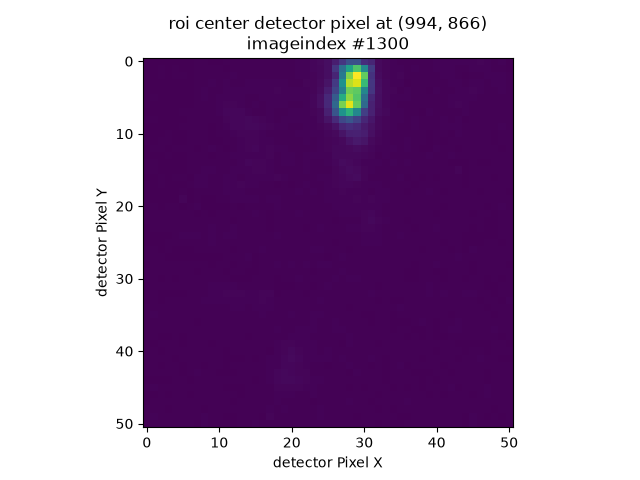

```python
# just to test a single imagelet
imageindex = imageindex0
vmax= None

print(imageindex//dimfast,imageindex%dimfast)
#-------------
if imageindex not in d['listindices']:
    raise ValueError('imageindex is not in the data !\n Try an other "imageindex" value')
roicenter = d['roicenter']
figt, axt = plt.subplots()
data2D  = mosaic[imageindex//dimfast,imageindex%dimfast]
if vmax is not None: vmax = max(np.amin(data2D)+1, vmax)
axt.imshow(data2D, origin='upper', vmax=vmax)
axt.set_title(f'roi center detector pixel at ({roicenter[0]}, {roicenter[1]})\nimageindex #{imageindex}')
axt.set_xlabel('detector Pixel X')
axt.set_ylabel('detector Pixel Y')

print('data2D.shape', data2D.shape)
print('initial roi size (X, Y)',2*boxsize_X+1, 2*boxsize_Y+1)
```

```python
print(bigimage.shape) # "Ypixel * slow", Xpixel * fast"
mosaic.shape # slow axis dimensions , fast axis dimensions, Ypixel, Xpixel
```

```
(2601, 2601)
```

```
(51, 51, 51, 51)
```

```python
# find the hottest imagelet   indices in mosaic darray
fullboxY = mosaic.shape[2]
fastdim = mosaic.shape[1]
fullboxX = mosaic.shape[3]

pixel_slowdirection, pixel_fastdirection = np.argmax(bigimage)//(fullboxX*fastdim), np.argmax(bigimage)%(fullboxX*fastdim)
#print(pixel_slowdirection, pixel_fastdirection)
i_slow_max = pixel_slowdirection//fullboxY
i_fast_max = pixel_fastdirection//fullboxX

print('max intensity in this ROI found in the map at')
print('indices : i_slow_max, i_fast_max', i_slow_max, i_fast_max)
```

```
max intensity in this ROI found in the map at
indices : i_slow_max, i_fast_max 26 29
```

## GUI browser imagelet

```
25 25
```

```
[interactive widget (ipywidgets)]
```

```
i_slow // xech   i_fast // yech
```

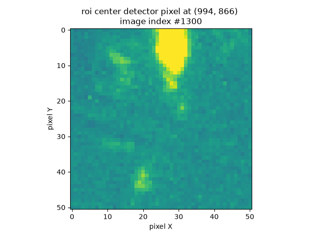

```python
dimfast = d['mapdimensions'][0]
roicenter = d['roicenter']
i_x0, i_y0 = imageindex0//dimfast,imageindex0%dimfast  # slow, fast

print(i_x0, i_y0)

figt, axt = plt.subplots()
axt.imshow(mosaic[i_x0, i_y0], origin='upper')

slider_ix = widgets.IntSlider(value=i_x0, min=0, max=mosaic.shape[0]-1, step=1)
slider_iy = widgets.IntSlider(value=i_y0, min=0, max=mosaic.shape[1]-1, step=1)
slider_vmin = widgets.IntSlider(value=0, min=-100, max=0, step=1)
slider_vmax = widgets.IntSlider(value=1000, min=10, max=60000, step=1)
output = widgets.Output()

def handle_slider_change(change):
    with output:
        output.clear_output()
        print(f"The new slider value is: {change.new}")

slider_ix.observe(handle_slider_change, 'value')
slider_iy.observe(handle_slider_change, 'value')

widgets.VBox([slider_ix,slider_iy, slider_vmin, slider_vmax, output])

def plotroi(i_slow, i_fast, vmin=0, vmax=8000, scale='linear'):
    ymin, ymax = axt.get_ylim()
    xmin, xmax = axt.get_xlim()

    i_x, i_y = i_slow, i_fast

    axt.clear()

    axt.set_xlim(xmin, xmax)
    axt.set_ylim(ymin, ymax)


    ymin, ymax, xmin, xmax = int(ymin),int(ymax),int(xmin),int(xmax)
    if ymin>ymax:
        yminc = ymin
        ymin = ymax
        ymax = yminc

    imageindex = i_x*dimfast+i_y

    if scale == 'linear':
        dplot = mosaic[i_x, i_y]
        vminplot = vmin
        vmaxplot = vmax
    elif scale == 'log':
        dplot = np.log10(mosaic[i_x, i_y])
        vminplot = np.log10(vmin)
        vmaxplot = np.log10(vmax)

    axt.imshow(dplot, origin='upper', vmin=vminplot, vmax=vmaxplot)
    axt.set_xlabel('pixel X')
    axt.set_ylabel('pixel Y')
    tt = f'roi center detector pixel at ({roicenter[0]}, {roicenter[1]}) '
    tt += f'\nimage index #{imageindex}'
    axt.set_title(tt)

    print('max:', np.amax(dplot))
    print('min:', np.amin(dplot))

widgets.interact(plotroi, i_slow=slider_ix,i_fast=slider_iy,
                 vmin = slider_vmin, vmax = slider_vmax, scale=['linear', 'log'])
print(f'i_slow // {d["slowaxis"]}   i_fast // {d["fastaxis"]}')
```

## visualisation mosaic for 2D scan (map)

```python
mosaic.shape
```

```
(51, 51, 51, 51)
```

```
(2601, 2601)
```

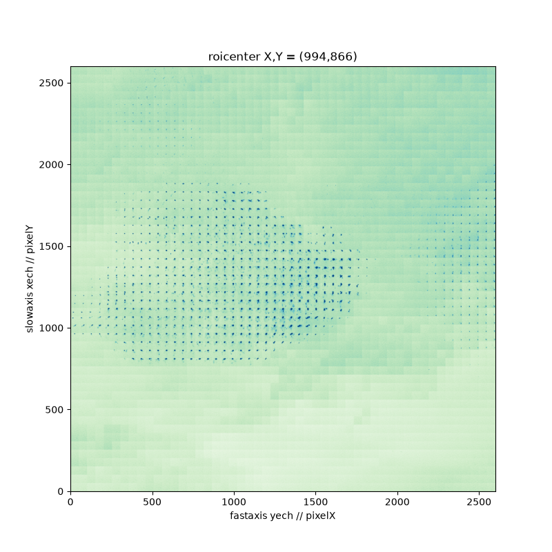

```python
# plot mosaic from 2D map
if d['scantype']=='map':
    vmax =  1000 # None

    #bigimage.shape # "Ypixel * slow", Xpixel * fast"
    #mosaic.shape # slow , fast , Ypixel, Xpixel
    def format_coord(x, y):
        col = int(x)
        row = int(y)
        if col >= 0 and col < bigimage.shape[1] and row >= 0 and row < bigimage.shape[0]:
            #cnt_idx = fig.gca()
            i, j = col//mosaic.shape[3], row//mosaic.shape[2]
            img_idx = 0+ mosaic.shape[1]*j+i
            return "x=%1.4f, y=%1.4f, imageid=%d" % (x, y,img_idx)
        else:
            return "x=%1.4f, y=%1.4f" % (x, y)




    print(bigimage.shape, )
    figmosaic, axmosaic = plt.subplots(figsize=(8,8))
    axmosaic.format_coord = format_coord
    axmosaic.imshow(bigimage, origin='lower', vmax=1000, cmap='GnBu')
    axmosaic.set_xlabel(f"fastaxis {d['fastaxis']} // pixelX")  # ok for fdscan2d
    axmosaic.set_ylabel(f"slowaxis {d['slowaxis']} // pixelY")
    title = ''
    title += '%s\n'%d['imagefolder']
    title += 'roicenter X,Y = (%d,%d)'%(d['roicenter'][0],d['roicenter'][1])
    axmosaic.set_title(title)
    axmosaic.format_coord = format_coord
```

# COLLECT ROI counters multiprocessing (including grqain imaging)

(setting collector, boxsizes)

```python
print('map dimensions:',d['mapdimensions'])
print('folder of Laue images:',d['folder'])
imageindexmax_in_folder = GT.get_largest_index_in_folder(d['folder'], filename_prefix=d['prefix'],
                                                         filename_suffix=d['suffix'])
print('Found largest image index in this folder:',imageindexmax_in_folder)
```

```
map dimensions: (51, 51)
folder of Laue images: /data/visitor/<proposal>/bm32/<date>/RAW_DATA/<sample>/<dataset>/scan0001
Found largest image index in this folder: 2600
```

```python
# checking if we have more images than expected
if imageindexmax_in_folder != max(d['listindices']):
    GT.printyellow(f'\nBe careful, this folder created by a scan may contain unexpected additional images')
    GT.printyellow(f"\nPlease use d['listindices'] to properly read the right number of images")
else:
    GT.printgreen(f'\nThis folder containing images created by a scan contains {max(d["listindices"])+1} images as expected from dict `d`')
```

```
This folder containing images created by a scan contains 2601 images as expected from dict `d`
```

```python
if 'intensities' in d:
    print( d['intensities'].shape)
nbrois = d['peaklist'].shape[0]
print(f'There are {nbrois} ROI centers (in peaklist) selected on detector {d['CCDLabel']}')
```

```
There are 441 ROI centers (in peaklist) selected on detector EIGER_4MCdTe
```

```python
maxdistancefromborder = 20 # will be the half boxsize used in the next cell!
if 1:
    framedim = DictLT.dict_CCD[d['CCDLabel']][0]
    print('framedim  (pixelY, pixelX)',framedim)

    pk0 = d['peaklist']

    print('maximum values (X, Y):',np.amax(d['peaklist'], axis=0))

    d['initialpeaklist'] = copy.copy(pk0)

    print('Checking and keeping peaks far from detector frame border')
    print('before',len(pk0))
    pk, totakeindices = RMCCD.filter_points_far_from_border(pk0, maxdistancefromborder,
                                                            maxdistancefromborder, d['CCDLabel'])
    print('after', len(pk))
    print(f"updating peaks list of d['peaklist']")
    d['peaklist'] = np.ndarray.astype(pk, np.int32)

    print('maximum values (X, Y):',np.amax(d['peaklist'], axis=0))

    if 'intensities' in d:
        if d['intensities'] is not None:
            d['intensities']= np.take(d['intensities'],totakeindices , axis=0)
    minX, maxX = np.min(d['peaklist'][:,0]),np.amax(d['peaklist'][:,0])
    minY, maxY = np.min(d['peaklist'][:,1]),np.amax(d['peaklist'][:,1])
    print(f'X ROIs center are comprised between: {minX}, {maxX}')
    print(f'Y ROIs center are comprised between: {minY}, {maxY}')
```

```
framedim  (pixelY, pixelX) (2162, 2068)
maximum values (X, Y): [2050 2050]
Checking and keeping peaks far from detector frame border
before 441
framedim  (pixelY, pixelX) (2162, 2068)
after 420
updating peaks list of d['peaklist']
maximum values (X, Y): [1950 2050]
X ROIs center are comprised between: 50, 1950
Y ROIs center are comprised between: 50, 2050
```

```python
print('largest X, Y pixel coordinates of all ROIs',np.amax(d['peaklist'], axis=0))
```

```
largest X, Y pixel coordinates of all ROIs [1950 2050]
```

```python
if __name__=='__main__':
    import itertools

    # True will deduce the last completed lines and modify map dimensions accordingly,
    # False: consider the scan completed (all images stored) or one can define our own listindices
    ONLINE=False  # True
    # -----------------INPUT ---------------------------------------
    # advised for 2D map
    #collector = 'roimax','roiXYmax' 'fitpeakXY' 'XYcenterofmass'
    # advised for daxm
    #collector = 'roimax', 'pixelval' 'sum'
    collector = 'roimax'

    nbcpus= 64 # > 1 !!

    computerrorbars = False

    # HALF boxsize (odd value to have centered box on central pixel)
    boxsize_X=7 # along pixel X
    boxsize_Y=7  # along pixel Y

    if  d['scantype'] == 'daxm':
        collector = 'roimax'
        boxsize_X=3  # 1
        boxsize_Y=1

    elif collector == 'pixelval':
        boxsize_X=None  # meaningless
        boxsize_Y=None


    dictparam=d

    folder=dictparam.get('folder', None)

    # images to be handled
    listindices = None#  None means take indices in d[['listindices']]
    nbcompletelines = None #10  # None all lines when scan is completed

    if ONLINE:
        nbcompletelines = GT.get_largest_index_in_folder(d['folder'], filename_prefix=d['prefix'],
                                                         filename_suffix=d['suffix'])//d['mapdimensions'][0]


    #---------------------Multiprocessing -----------------------------------------------
    if maxX + boxsize_X>framedim[1] or minX - boxsize_X<0:
        raise ValueError('boxsize_X is too large')
    if maxY + boxsize_Y>framedim[0] or minY - boxsize_Y<0:
        raise ValueError('boxsize_Y is too large')

    if collector == 'fitpeakXY':
        computerrorbars = False # True

    maxnbcpus = cpu_count()
    if nbcpus is None:
        nbcpus = maxnbcpus
    else:
        nbcpus = max(2,min(nbcpus,maxnbcpus))
    print('nbcpus', nbcpus)

    peaklist=dictparam.get('peaklist', None)
    prefix=dictparam.get('prefix', None)

    CCDLabel=dictparam.get('CCDLabel', 'sCMOS')

    nbpeaks = len(dictparam['peaklist'])

    if listindices is None:
        listindices=dictparam['listindices']
        if nbcompletelines is not None:
            listindices=dictparam['listindices'][:d['nbimagesperline']*nbcompletelines]

    if not isinstance(folder, list):  # iteration over images on the same folder
        nbimages = len(listindices)
        listfolders = itertools.repeat(folder)

    else: # iteration over a list of folder
        print('Multiple folders screened')
        nbimages = len(folder)
        listfolders = folder
        listindices = itertools.repeat(dictparam['listindices'])


    #----------------------------------

    t00 = time.time()
    print(f'using {collector} as collector: {nbimages} images, {nbpeaks} roi positions, {nbcpus} cpu(s)')

    args_pixelvalue = zip(listindices,
                   itertools.repeat(peaklist),
                   itertools.repeat(prefix),
                   listfolders,
                   itertools.repeat(CCDLabel),
                   )

    args_roimax = zip(listindices,
                   itertools.repeat(peaklist),
                   itertools.repeat(prefix),
                   listfolders,
                  itertools.repeat(boxsize_X),
                  itertools.repeat(boxsize_Y),
                   itertools.repeat(CCDLabel),
                   )

    args_roimax_errorbars = zip(listindices,
                   itertools.repeat(peaklist),
                   itertools.repeat(prefix),
                   listfolders,
                  itertools.repeat(boxsize_X),
                  itertools.repeat(boxsize_Y),
                   itertools.repeat(CCDLabel),
                    itertools.repeat(computerrorbars)
                   )

    #print('args_pixelvalue',[elem for elem in args_pixelvalue])

    with multiprocessing.Pool(nbcpus) as pool:

        assert len(peaklist)>0

        if collector == 'pixelval': # 1 scalar /roi
            print("collectpixelvalue_singlefile")
            allresults = pool.starmap(collectpixelvalue_singlefile,
                                      tqdm(args_pixelvalue, total=nbimages,
                                      desc='pixel values progress bar:'))

        elif collector == 'sum': # 1 scalar /roi

            allresults = pool.starmap(collectroissum_singlefile,
                                      tqdm(args_roimax, total=nbimages,
                                      desc='sum values progress bar:'), chunksize=1)
        elif collector == 'roimax':

            allresults = pool.starmap(collectroismax_singlefile,
                                      tqdm(args_roimax, total=nbimages,
                                      desc='max values progress bar:'), chunksize=1)
            #collectroismax_singlefile.__defaults__=(peaklist,prefix,folder,boxsize_X,boxsize_Y,CCDLabel)
            #allresults = pool.map(collectroismax_singlefile, tqdm(listindices))

        elif collector == 'roiXYmax': #  2 values/roi

            allresults = pool.starmap(collectroisXYmax_singlefile,
                                      tqdm(args_roimax, total=nbimages,
                                      desc='pixel positions progress bar:'))

        elif collector == 'fitpeakXY':  # 7 values/roi
            allresults = pool.starmap(collectroisfitpeak_singlefile,
                                      tqdm(args_roimax_errorbars, total=nbimages,
                                      desc='fitted positions progress bar:'), chunksize=1)
        elif collector == 'XYcenterofmass': #  2 values/roi
            allresults = pool.starmap(collectroisXYcenterofmass_singlefile,
                                      tqdm(args_roimax, total=nbimages,
                                      desc='pixel positions progress bar:'))

    allresults = np.array(allresults)

    elapsedtime=time.time()-t00
    print(f'total time is {elapsedtime:.3f} sec for {nbimages} images, {nbpeaks} roi positions and {nbcpus} cpu(s)')

    children = active_children()
    print(f'Active children: {len(children)}')

    d['allresults']=allresults
    GT.printgreen('Results are in allresults or allresults key...\n\n!!! ----- Collection done ;-) ----!!')
```

```
nbcpus 40
using roimax as collector: 2601 images, 420 roi positions, 40 cpu(s)
```

```
total time is 10.047 sec for 2601 images, 420 roi positions and 40 cpu(s)
Active children: 0
Results are in allresults or allresults key...

!!! ----- Collection done ;-) ----!!
```

```python
allresults.shape
```

```
(2601, 420)
```

## pickling results

```python
ExperimentFolder, folder
```

```
('/data/visitor/<proposal>/bm32/<date>/RAW_DATA/',
 '/data/visitor/<proposal>/bm32/<date>/RAW_DATA/<sample>/<dataset>/scan0001')
```

### create mirror folder in PROCESSED_DATA and GALLERY

```python
folder= d['folder']

print('raw data folder (where images are saved from a given scan)', folder)
#---------------------------------------------
# creating Folder for processed data
if not isinstance(folder, list):   # single folder
    # write in PROCESSED_DATA
    genfolder, galleryfolder = bf.createmirrorfolder(folder)

elif 'projects' in ExperimentFolder:
    # in projects/mapgrainxl  there is no 'PROCESSED_DATA'
    genfolder = folder
    galleryfolder = os.path.join(os.path.split(ExperimentFolder)[0],'GALLERY')

else:
    genfolder = os.path.join(os.path.split(ExperimentFolder)[0],'PROCESSED_DATA')
    galleryfolder = os.path.join(os.path.split(ExperimentFolder)[0],'GALLERY')

os.makedirs(genfolder, exist_ok=True)
os.makedirs(galleryfolder, exist_ok=True)

print('analysis results will be written is "genfolder":\n',genfolder)
print('images results will be written is "galleryfolder":\n',galleryfolder)
```

```
raw data folder (where images are saved from a given scan) /data/visitor/<proposal>/bm32/<date>/RAW_DATA/<sample>/<dataset>/scan0001
/data/visitor/<proposal>/bm32/<date>/PROCESSED_DATA/<sample>/<dataset>/scan0001/ folder has been created
/data/visitor/<proposal>/bm32/<date>/GALLERY/<sample>/<dataset>/scan0001/ folder has been created
analysis results will be written is "genfolder":
 /data/visitor/<proposal>/bm32/<date>/PROCESSED_DATA/<sample>/<dataset>/scan0001/
images results will be written is "galleryfolder":
 /data/visitor/<proposal>/bm32/<date>/GALLERY/<sample>/<dataset>/scan0001/
```

```python
#---------------------------------------------
# use genfolder to write output  results
import pickle

if 0: # SAVE

    nbcounters = len(d['peaklist'])
    dictresults=copy.copy(d)
    dictresults['allresults']=allresults

    picklefile = os.path.join(genfolder,'%s_%dcounters.pickle'%(collector,nbcounters))

    with open(picklefile, 'wb') as f:
        pickle.dump(dictresults, f)

    GT.printgreen(f'picklefile saved in {picklefile}')

if 0: #LOAD
    if input('Are you sure to load a previous file and overwrite dictresults?') in ('y','yes','Y','YES','o','O'):

        folder = '/data/visitor/<proposal>/bm32/<date>/SiCnuit/SiCnuit_bulle2/scan0001'
        collector = 'fitpeakXY'
        #folder = d['folder']

        #fullpathpickle = os.path.join(genfolder,'%s_20counters.pickle'%collector)
        fullpathpickle = '/data/visitor/<proposal>/bm32/<date>/PROCESSED_DATA/<sample>/<dataset>/scan0002/roimax_740counters.pickle'
        with open(fullpathpickle, 'rb') as f:
            dictresults=pickle.load(f)
        allresults = dictresults['allresults']
        d=dictresults
        collector= d['collector']
```

```python
#d
```

## Arrange collected data.

BUILD `tr` array from collected `allresults`

SET scalar X or Y component for `collector` = 'roiXYmax' or 'fitpeakXY'

```python
#peak component selection  (only if 'roiXYmax' or 'fitpeakXY' collected data)

if collector in ('fitpeakXY','roiXYmax', 'test'):
    peakposcomponent = input('Which pixel coordinate do you choose ? (X, Y)')
    # peakposcomponent='X'
    # peakposcomponent='Y'
    print(f'peakposcomponent is {peakposcomponent}')

print('(nb images, nb rois, nb vals / roi)',allresults.shape)
print('collector:',collector)

if collector in ('sum','roimax','pixelval',):
    tr = np.transpose(allresults)

    collectortitle=collector #just for visualisation

    spatialcoord = ''

elif collector in ('fitpeakXY',):
    # bke, amp, xfit, yfit, std1, std2, orientangle,  [errorbars] ?
    bkg  = allresults[:,:,0]
    amp = allresults[:,:,1]
    xfit, yfit = np.transpose(allresults[:,:,2:4])

    spatialcoord = peakposcomponent

    if peakposcomponent == 'X':
        tr = xfit
    if peakposcomponent == 'Y':
        tr = yfit
    collectortitle=collector #just for visualisation
else:
    tr_x = np.transpose(allresults[:,:,0])
    tr_y = np.transpose(allresults[:,:,1])

    spatialcoord = peakposcomponent

    # selecting X value
    if peakposcomponent=='X':
        tr = tr_x
    else: # selecting Y value
        tr = tr_y
    collectortitle=collector+'_%s'%peakposcomponent #just for visualisation

print('nb rois:',tr.shape[0])
print('nb images:',tr.shape[1])
print('map dimensions:',d['mapdimensions'])
print('map nb of dimensions:',len(d['mapdimensions']))
print('Chosen scalar to map in 2D:', collectortitle)
print('scan type:', d['scantype'])
if d['scantype']=='map':
    GT.printgreen('Your data are 2D, so use rather section VISUALIZE 2D case')
elif d['scantype']=='daxm':
    GT.printgreen('Your data are 1D, so use rather section VISUALIZE 1D case')
```

```
(nb images, nb rois, nb vals / roi) (2601, 420)
collector: roimax
nb rois: 420
nb images: 2601
map dimensions: (51, 51)
map nb of dimensions: 2
Chosen scalar to map in 2D: roimax
scan type: map
Your data are 2D, so use rather section VISUALIZE 2D case
```

# VISUALIZE: 2D case (amesh dmesh fdmap)

this section is useful only if d['scantype']=='map'

```python
# Advice
if not d['scantype']=='map':
    print(f'2D visualisation is not appropriate for your scan since d["scantype"]="{d["scantype"]}" is not "map".\nGo better to the next section!')
```

### some helpers functions

```python
def getxechyech(imageindex,dictparam):
    fullcommand = dictparam['fullcommand']
    print('fullcommand :',fullcommand)
    assert imageindex>0

    if fullcommand.startswith('amesh'):
        _, fastmotor, fm_min, fm_max, fm_nbsteps, slowmotor, sm_min, sm_max, sm_nbsteps, expo = fullcommand.split()
    elif fullcommand.startswith('fscan2d'):
        _, slowmotor, sm_min, sm_stepsize, sm_dimension, fastmotor, fm_min, fm_stepsize, fm_dimension, _, expo = fullcommand.split()
        fm_nbsteps = int(fm_dimension) -1
        sm_nbsteps = int(sm_dimension) -1
        fm_max = float(fm_min) + fm_nbsteps*float(fm_stepsize)
        sm_max = float(sm_min) + sm_nbsteps*float(sm_stepsize)

    dim = (int(fm_nbsteps)+1, int(sm_nbsteps)+1)
    if imageindex>dim[0]*dim[1]:
        GT.printred('imageindex too large!')
        return None
    fm_step = (float(fm_max)-float(fm_min))/int(fm_nbsteps)
    sm_step = (float(sm_max)-float(sm_min))/int(sm_nbsteps)
    fmname = fastmotor
    smname = slowmotor

    index_row, index_col = imageindex//dim[0], imageindex%dim[0]
    fm_val = float(fm_min) + index_col*float(fm_step)
    sm_val = float(sm_min) + index_row*float(sm_step)
    return {fmname: fm_val, smname:sm_val}

def convertindex2Dto1D(fastindex, slowindex, mapdimensions:'(nfast, nslow)'=None):
    nf, _ = mapdimensions
    return slowindex*nf+fastindex

def convertindex1Dto2D(index, mapdimensions:'(nfast, nslow)'=None):
    nf, _ = mapdimensions
    fastindex = index%nf
    slowindex = index//nf
    return fastindex,slowindex

getxechyech(55,d)
```

```
fullcommand : amesh yech -6.43556 -6.28556 50 xech 0.94557 1.09557 50 0.5
```

```
{'yech': -6.42356, 'xech': 0.94857}
```

### multiple plot of map obtained from several roi counters

```
Total Number of counters to plot: 24
Highest selected index: 23
```

```
[interactive widget (ipywidgets)]
```

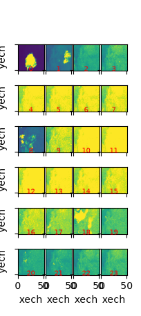

```python
import numpy as np
import matplotlib.pyplot as plt
from ipywidgets import interact, FloatSlider, Checkbox, Output
from IPython.display import display

# --- Select counters ---
list_idx_counters = range(24, 24 + 23)  # Example: 23 counters starting from 24
list_idx_counters = range(3788, 3788 + 15)  # Example: 23 counters starting from 24
list_idx_counters = range(0,24)

autocontrast = True  # Default: autocontrast enabled
nbcols = 4  # Number of columns for subplots

# --- Validate counters ---
nbcounters = len(list_idx_counters)
print(f"Total Number of counters to plot: {nbcounters}")
print(f"Highest selected index: {max(list_idx_counters)}")

if max(list_idx_counters) > len(tr):
    raise ValueError(f"Maximum counter index is {len(tr) - 1}. And you ask to plot data for counter #{max(list_idx_counters)}")

# --- Subplot layout ---
nbimagesperline = d['nbimagesperline']
nrows = (nbcounters + nbcols - 1) // nbcols  # Ceiling division

# --- Dynamic figure size ---
fastdim, slowdim = d['mapdimensions']
subplot_width_inches = slowdim / 100
subplot_height_inches = fastdim / 100
fig_width = nbcols * subplot_width_inches
fig_height = nrows * subplot_height_inches + 1.5  # Extra space for widgets

# --- Create figure and subplots ---
fig2, axs = plt.subplots(
    nrows=nrows,
    ncols=nbcols,
    sharex=True,
    sharey=True,
    figsize=(fig_width, fig_height)
)

# --- Flatten axes for iteration ---
axs_flat = axs.flatten() if nrows > 1 else [axs]

# --- Missing plot placeholder ---
if d['fastaxis'] in ('xech', 'xps'):
    missingplot = np.zeros_like(tr[0]).reshape((-1, nbimagesperline))
else:  # 'yech' or 'yps'
    missingplot = np.zeros_like(tr[0]).reshape((-1, nbimagesperline)).T

# --- Coordinate formatting ---
def format_coord(x, y):
    fastdim, slowdim = d['mapdimensions']
    col, row = int(x + 0.5), int(y + 0.5)

    if d['fastaxis'] in ('xech', 'xps'):
        if 0 <= col < fastdim and 0 <= row < slowdim:
            img_idx = nbimagesperline * row + col
    elif d['fastaxis'] in ('yech', 'yps'):
        if 0 <= col < slowdim and 0 <= row < fastdim:
            img_idx = nbimagesperline * col + row
        else:
            return f"x={x:.4f}, y={y:.4f}, intensity"
    else:
        return f"x={x:.4f}, y={y:.4f}, intensity"

    return f"x={x:.4f}, y={y:.4f}, imageid={img_idx}, intensity"

# --- Initial vmin and vmax values ---
initial_vmin = 0
initial_vmax = 100

# --- Store clicked points ---
clicked_points_list = []

# --- Store image indices for each subplot ---
image_indices = {}

# --- Plot data ---
def update_plots(autocontrast, vmin, vmax, save_clicked_points):
    global image_indices
    image_indices = {}  # Reset image indices
    k = 0
    for i, ax in enumerate(axs_flat):
        row = i // nbcols  # Current row index
        col = i % nbcols   # Current column index

        if k < nbcounters:
            _idx = list_idx_counters[k]
            roidata = tr[_idx]

            # Reshape and transpose logic
            transdata = roidata.reshape((-1, nbimagesperline))
            if d.get('fastaxis') in ('xech', 'xps'):
                xlabel, ylabel = d['fastaxis'], d['slowaxis']
            elif d.get('fastaxis') in ('yech', 'yps'):
                transdata = transdata.T
                xlabel, ylabel = d['slowaxis'], d['fastaxis']
            else:
                xlabel, ylabel = 'xech', 'yech'

            # Apply vmin and vmax
            current_vmin = None if autocontrast else vmin
            current_vmax = None if autocontrast else vmax

            if autocontrast:
                if d['CCDLabel'] == 'sCMOS':
                    current_vmin, current_vmax = 1010, max(1010, 0.75 * np.amax(roidata))
                else:
                    current_vmin, current_vmax = 0, max(200, 0.25 * np.amax(roidata))

            ax.clear()
            ax.imshow(transdata, origin='lower', vmin=current_vmin, vmax=current_vmax)
            ax.format_coord = format_coord
            ax.text(0.5, 0.05, f"{_idx}",
                    ha='center', va='center', fontsize=7, color='red',
                    transform=ax.transAxes)

            # Store image index for this subplot
            image_indices[ax] = _idx

            # Only set xlabel for the bottom row
            if row == nrows - 1:
                ax.set_xlabel(xlabel)
            else:
                ax.set_xticklabels([])  # Remove x-tick labels for non-bottom rows

            # Only set ylabel for the first column
            if col == 0:
                ax.set_ylabel(ylabel)
            else:
                ax.set_yticklabels([])  # Remove y-tick labels for non-first columns

            k += 1
        else:
            ax.clear()
            ax.imshow(missingplot, origin='lower')
            ax.text(0.5, 0.5, 'no data',
                    ha='center', va='center', fontsize=5, color='red',
                    transform=ax.transAxes)
            ax.axis('on')



    # Connect click event to save points if checkbox is checked
    if save_clicked_points:
        fig2.canvas.mpl_connect('button_press_event', on_click)
    else:
        fig2.canvas.mpl_disconnect(fig2.canvas.mpl_connect('button_press_event', on_click))

    plt.subplots_adjust(hspace=0.05, wspace=0.05)


    fig2.suptitle(d['imagefolder'], fontsize=8)
    fig2.canvas.draw_idle()

# --- Click event handler ---
def on_click(event):
    if event.inaxes:
        ax = event.inaxes
        x, y = event.xdata, event.ydata
        print(f'point: x={x:.0f}, y={y:.0f}')
        if ax in image_indices:
            _idx = image_indices[ax]
            # Calculate imageid using format_coord logic
            coord_text = format_coord(x, y)
            # Extract imageid from the formatted string
            imageid = int(coord_text.split("imageid=")[1].split(",")[0]) if "imageid=" in coord_text else None
            clicked_points_list.append((int(x), int(y), imageid))
            print(f"Saved point: x={x:.0f}, y={y:.0f}, imageid={imageid}")

# --- Create widgets ---
autocontrast_checkbox = Checkbox(
    value=True,
    description='Autocontrast',
    disabled=False,
    indent=False
)

save_clicked_points_checkbox = Checkbox(
    value=False,
    description='Save Clicked Points',
    disabled=False,
    indent=False
)

vmin_slider = FloatSlider(
    value=initial_vmin,
    min=-1000,
    max=1000,
    step=1,
    description='vmin:',
    disabled=False,
    continuous_update=True
)

vmax_slider = FloatSlider(
    value=initial_vmax,
    min=-1000,
    max=1000,
    step=1,
    description='vmax:',
    disabled=False,
    continuous_update=True
)

# --- Link widgets to update function ---
interact(
    update_plots,
    autocontrast=autocontrast_checkbox,
    vmin=vmin_slider,
    vmax=vmax_slider,
    save_clicked_points=save_clicked_points_checkbox
)

# --- Initial plot ---
update_plots(autocontrast=True, vmin=initial_vmin, vmax=initial_vmax, save_clicked_points=False)

# --- Display the figure ---
plt.show()
```

```python
clicked_points_list
```

```
[(24, 16, 1291), (40, 29, 2121), (9, 29, 540)]
```

```python
def getposition(d, img_idx_list):
    """
    Retrieve (fastaxis, slowaxis) coordinates for a list of image indices given the scan dictionary
    and the access to the local h5 file created by BLISS.

    Args:
        d (dict): Dictionary containing metadata (e.g., 'fullcommand', 'localhdf5file', 'scanindex', 'fastaxis', 'slowaxis').
        img_idx_list (list or int): A list of image indices or a single image index.

    Returns:
        list: A list of dictionaries, where each dictionary contains the (fastaxis, slowaxis) coordinates for the corresponding img_idx.
              If img_idx_list is a single integer, returns a list with one dictionary.
    """
    # Convert single img_idx to a list for uniform processing
    if isinstance(img_idx_list, int):
        img_idx_list = [img_idx_list]

    # Initialize the list to store results
    position_list = []

    # Retrieve fastaxis and slowaxis data
    if d['fullcommand'].startswith('fscan2d') :
        if d['fullcommand'].split()[5] in ('yps', 'yech'):
            with h5py.File(d['localhdf5file'], locking=False) as f:
                fastaxis_value = f[f'{d["scanindex"]}.1/instrument/{d["fastaxis"]}/data'][()]
                slowaxis_value = f[f'{d["scanindex"]}.1/instrument/{d["slowaxis"]}/value'][()]
    elif d['fullcommand'].startswith('amesh'):
        if d['fullcommand'].split()[5] in ('xps', 'xech', 'sx'):
            with h5py.File(d['localhdf5file'], locking=False) as f:
                fastaxis_value = f[f'{d["scanindex"]}.1/instrument/{d["fastaxis"]}/value'][()]
                slowaxis_value = f[f'{d["scanindex"]}.1/instrument/{d["slowaxis"]}/value'][()]
    else:
        print('WARNING !!! Not able to parse the fullcommand:',d['fullcommand'])

    fa = d['fastaxis']
    sa = d['slowaxis']

    # Iterate over each img_idx in the list
    for img_idx in img_idx_list:
        position_list.append({
            fa: float(np.round(fastaxis_value[img_idx], 4)),
            sa: float(np.round(slowaxis_value[img_idx], 4))
        })

    return position_list

_,_,img_idx = clicked_points_list[-1]
list_img_idx = [_idx for _,_,_idx in clicked_points_list]

print('images with indices', list_img_idx)
print('were taken resp. at sample position', getposition(d, list_img_idx))
```

```
images with indices [1291, 2121, 540]
were taken resp. at sample position [{'yech': -6.3876, 'xech': 1.0206}, {'yech': -6.3456, 'xech': 1.0686}, {'yech': -6.3456, 'xech': 0.9756}]
```

```
Number of counters to plot: 24
Highest selected index: 23
```

```
[interactive widget (ipywidgets)]
```

```
[interactive widget (ipywidgets)]
```

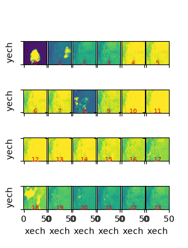

```python
import numpy as np
import matplotlib.pyplot as plt
from ipywidgets import interact, FloatSlider, Checkbox, Button, Output
from IPython.display import display

# --- Select counters ---
list_idx_counters = range(0, 24)  # Example: 23 counters starting from 24
autocontrast = True  # Default: autocontrast enabled
nbcols = 6 # Number of columns for subplots

# --- Validate counters ---
nbcounters = len(list_idx_counters)
print(f"Number of counters to plot: {nbcounters}")
print(f"Highest selected index: {max(list_idx_counters)}")

if max(list_idx_counters) > len(tr):
    raise ValueError(f"Maximum counter index is {len(tr) - 1}")

# --- Subplot layout ---
nbimagesperline = d['nbimagesperline']
nrows = (nbcounters + nbcols - 1) // nbcols  # Ceiling division

# --- Dynamic figure size ---
fastdim, slowdim = d['mapdimensions']
subplot_width_inches = slowdim / 100
subplot_height_inches = fastdim / 100
fig_width = nbcols * subplot_width_inches
fig_height = nrows * subplot_height_inches + 2.0  # Extra space for widgets

# --- Create figure and subplots ---
fig2, axs2 = plt.subplots(
    nrows=nrows,
    ncols=nbcols,
    sharex=True,
    sharey=True,
    figsize=(fig_width, fig_height)
)

# --- Flatten axes for iteration ---
axs_flat2 = axs2.flatten() if nrows > 1 else [axs2]

# --- Missing plot placeholder ---
if d['fastaxis'] in ('xech', 'xps'):
    missingplot = np.zeros_like(tr[0]).reshape((-1, nbimagesperline))
else:  # 'yech' or 'yps'
    missingplot = np.zeros_like(tr[0]).reshape((-1, nbimagesperline)).T

# --- Coordinate formatting ---
def format_coord(x, y):
    fastdim, slowdim = d['mapdimensions']
    col, row = int(x + 0.5), int(y + 0.5)

    if d['fastaxis'] in ('xech', 'xps'):
        if 0 <= col < fastdim and 0 <= row < slowdim:
            img_idx = nbimagesperline * row + col
            return img_idx
    elif d['fastaxis'] in ('yech', 'yps'):
        if 0 <= col < slowdim and 0 <= row < fastdim:
            img_idx = nbimagesperline * col + row
            return img_idx
    return None

# --- Initial vmin and vmax values ---
initial_vmin = 0
initial_vmax = 50000

# --- Global list to store selected regions ---
selected_regions = []

# --- Track the last active subplot (for click) ---
last_active_subplot = None

# --- Function to update the last active subplot ---
def on_click(event):
    global last_active_subplot
    if event.inaxes:
        last_active_subplot = event.inaxes

# Connect the click event to track the last active subplot
fig2.canvas.mpl_connect('button_press_event', on_click)

# --- Function to capture the selected region and compute image indices as a 2D array ---
def capture_selected_region(b):
    global selected_regions, last_active_subplot
    print("Capture button clicked!")  # Debug message

    if last_active_subplot is None:
        print("No subplot was clicked. Please click on a subplot first.")
        return

    # Find the index of the last active subplot
    subplot_index = None
    for i, ax in enumerate(axs_flat2):
        if ax == last_active_subplot:
            subplot_index = i
            break

    if subplot_index is None or subplot_index >= nbcounters:
        print("No valid subplot found or subplot index out of range.")
        return

    ax = last_active_subplot
    xlim = ax.get_xlim()
    ylim = ax.get_ylim()

    # Iterate over all pixels in the visible region
    x_min, x_max = int(np.floor(xlim[0])), int(np.ceil(xlim[1]))
    y_min, y_max = int(np.floor(ylim[0])), int(np.ceil(ylim[1]))

    # Create a 2D array for the visible region
    region_array = np.full((y_max - y_min + 1, x_max - x_min + 1), None, dtype=object)

    for x in range(x_min, x_max + 1):
        for y in range(y_min, y_max + 1):
            img_idx = format_coord(x, y)
            region_array[y - y_min, x - x_min] = img_idx

    # Calculate barycenter (center of the rectangle)
    barycenter_x = (x_min + x_max) / 2
    barycenter_y = (y_min + y_max) / 2
    barycenter_img_idx = format_coord(barycenter_x, barycenter_y)

    # Calculate area (number of valid imageindex elements)
    area = np.count_nonzero(region_array != None)

    # Append region info to selected_regions
    selected_regions.append({
        'subplot_index': list_idx_counters[subplot_index],
        'region_array': region_array,
        'barycenter_imageindex': barycenter_img_idx,
        'barycenter_x': barycenter_x,
        'barycenter_y': barycenter_y,
        'area': area
    })

    print(f"Captured region for subplot {subplot_index}. Total regions: {len(selected_regions)}")

# --- Create a button widget for capturing the selected region ---
capture_button = Button(description="Capture Selected Region")
capture_button.on_click(capture_selected_region)

# --- Plot data ---
def update_plots(autocontrast, vmin, vmax):
    k = 0
    for i, ax in enumerate(axs_flat2):
        row = i // nbcols  # Current row index
        col = i % nbcols   # Current column index

        if k < nbcounters:
            _idx = list_idx_counters[k]
            roidata = tr[_idx]

            # Reshape and transpose logic
            transdata = roidata.reshape((-1, nbimagesperline))
            if d.get('fastaxis') in ('xech', 'xps'):
                xlabel, ylabel = d['fastaxis'], d['slowaxis']
            elif d.get('fastaxis') in ('yech', 'yps'):
                transdata = transdata.T
                xlabel, ylabel = d['slowaxis'], d['fastaxis']
            else:
                xlabel, ylabel = 'xech', 'yech'

            # Apply vmin and vmax
            current_vmin = None if autocontrast else vmin
            current_vmax = None if autocontrast else vmax

            if autocontrast:
                if d['CCDLabel'] == 'sCMOS':
                    current_vmin, current_vmax = 1010, max(1010, 0.75 * np.amax(roidata))
                else:
                    current_vmin, current_vmax = 0, max(200, 0.25 * np.amax(roidata))

            ax.clear()
            im = ax.imshow(transdata, origin='lower', vmin=current_vmin, vmax=current_vmax)
            ax.text(0.5, 0.05, f"{_idx}",
                    ha='center', va='center', fontsize=7, color='red',
                    transform=ax.transAxes)

            # Only set xlabel for the bottom row
            if row == nrows - 1:
                ax.set_xlabel(xlabel)
            else:
                ax.set_xticklabels([])  # Remove x-tick labels for non-bottom rows

            # Only set ylabel for the first column
            if col == 0:
                ax.set_ylabel(ylabel)
            else:
                ax.set_yticklabels([])  # Remove y-tick labels for non-first columns

            k += 1
        else:
            ax.clear()
            ax.imshow(missingplot, origin='lower')
            ax.text(0.5, 0.5, 'no data',
                    ha='center', va='center', fontsize=5, color='red',
                    transform=ax.transAxes)
            ax.axis('on')

    plt.subplots_adjust(hspace=0.05, wspace=0.05)
    fig2.canvas.draw_idle()

# --- Create widgets ---
autocontrast_checkbox = Checkbox(
    value=True,
    description='Autocontrast',
    disabled=False,
    indent=False
)

vmin_slider = FloatSlider(
    value=initial_vmin,
    min=-1000,
    max=50000,
    step=100,
    description='vmin:',
    disabled=False,
    continuous_update=True
)

vmax_slider = FloatSlider(
    value=initial_vmax,
    min=-1000,
    max=50000,
    step=100,
    description='vmax:',
    disabled=False,
    continuous_update=True
)

# --- Link widgets to update function ---
interact(
    update_plots,
    autocontrast=autocontrast_checkbox,
    vmin=vmin_slider,
    vmax=vmax_slider
)

# --- Display the button widget ---
display(capture_button)

# --- Initial plot ---
update_plots(autocontrast=True, vmin=initial_vmin, vmax=initial_vmax)

# --- Display the figure ---
plt.show()

# --- Print the list of selected regions (for testing) ---
for region_idx, region in enumerate(selected_regions):
    print(f"Region {region_idx + 1}:")
    print(f"  Subplot index: {region['subplot_index']}")
    print(f"  Barycenter (x, y): ({region['barycenter_x']:.2f}, {region['barycenter_y']:.2f})")
    print(f"  Barycenter imageindex: {region['barycenter_imageindex']}")
    print(f"  Area (number of valid imageindices): {region['area']}")
    print(f"  Region array shape: {region['region_array'].shape}")
```

```python
# --- Print the list of selected regions (for testing) ---
for region_idx, region in enumerate(selected_regions):
    print(f"Region {region_idx + 1}:")
    print(f"  Subplot index: {region['subplot_index']}")
    print(f"  Barycenter (x, y): ({region['barycenter_x']:.2f}, {region['barycenter_y']:.2f})")
    print(f"  Barycenter imageindex: {region['barycenter_imageindex']}")
    print(f"  Area (number of valid imageindices): {region['area']}")
    print(f"  Region array shape: {region['region_array'].shape}")
    region_array=region['region_array']
    print(f"  Sample of region array: \n{np.array([
            [region_array[0, 0], region_array[0, -1]],
            [region_array[-1, 0], region_array[-1, -1]]
        ])}")  # Print 4 corners
```

```
Region 1:
  Subplot index: 0
  Barycenter (x, y): (24.00, 18.00)
  Barycenter imageindex: 1242
  Area (number of valid imageindices): 1221
  Region array shape: (37, 33)
  Sample of region array:
[[ 408 2040]
 [ 444 2076]]
```

## save figure and peaks/rois coordinates

```python
import time

outputfolder = galleryfolder
#outputfolder =  d['folder']

# ----  output filename business  -------
nameout = d.get('title','')
tt =time.asctime().strip()
tt = tt.replace(' ','_')
tt=tt.replace(':','_')
coltime="%s_%s_%s"%(collector,spatialcoord,tt)

if nameout != '':
    nameout+='_'+coltime
else:
    nameout=coltime
#---------------------------
print(nameout)
#--------------------------
lcnt = tuple(list_idx_counters)
xsel, ysel = np.take(d['peaklist'],lcnt , axis=0).T
ct_indices = np.array(lcnt)
selected_peaks=np.array([ct_indices,xsel,ysel]).T
coordfile = "roicoordinates_%s.dat"%nameout

with open(os.path.join(d['folder'],coordfile),'w') as f:
    np.savetxt(f, selected_peaks, header='roi_index, X, Y')
# -------------------

plt.savefig(os.path.join(outputfolder,nameout+'.png'))
print('output folder --->', outputfolder)
print('figure filename --->',nameout+'.png')
print('roi coordinates filename ---->',coordfile)
```

### single map from 1 counter

```python
# Select counters
idx_counter =0
outputfolder = galleryfolder

# Output filename business
nameout = d.get('title', '')
tt = time.asctime().strip().replace(' ', '_').replace(':', '_')
coltime = f"{collector}_{spatialcoord}_{tt}"
nameout = f"{nameout}_{coltime}" if nameout else coltime

print('nbimagesperline', nbimagesperline)
xy = np.take(d['peaklist'], idx_counter, axis=0)

def format_coord2(x, y):
    if d['fastaxis'] in ('yech', 'yps'):
        col = int(y + 0.5)
        row = int(x + 0.5)
        nfast, nslow = d['mapdimensions']
    else:
        col = int(x + 0.5)
        row = int(y + 0.5)
        nslow, nfast = d['mapdimensions']

    if 0 <= col < nfast and 0 <= row < nslow:
        img_idx = nbimagesperline * row + col
        return f"x={x:1.4f}, y={y:1.4f}, imageid={img_idx}"
    return f"x={x:1.4f}, y={y:1.4f}"

# Create an output widget to display the plot
plot_output = widgets.Output()

# Display the plot in the output widget
with plot_output:
    fig3, ax = plt.subplots(figsize=(8, 6))
    dd = tr[idx_counter]

    if autocontrast:
        vmin, vmax = np.amin(dd), np.amax(dd)
    else:
        vmin, vmax = None, None

    # Reshape data based on fastaxis
    if 'fastaxis' not in d:
        transdata = roidata.reshape((-1, nbimagesperline))
        xlabel, ylabel = 'xech', 'yech'
    else:
        if d['fastaxis'] in ('xech', 'xps'):
            transdata = roidata.reshape((-1, nbimagesperline)).T
            xlabel, ylabel = d['fastaxis'], d['slowaxis']
        elif d['fastaxis'] in ('yech', 'yps'):
            transdata = roidata.reshape((-1, nbimagesperline))
            xlabel, ylabel = d['fastaxis'], d['slowaxis']

    # Plot the data
    im = ax.imshow(transdata, origin='lower', vmin=vmin, vmax=vmax)
    ax.set_title(f"{collectortitle} {spatialcoord}\nroi #{idx_counter} centered on X,Y = {xy[0]:.1f}, {xy[1]:.1f}")
    ax.format_coord = format_coord2
    ax.set_xlabel(xlabel)
    ax.set_ylabel(ylabel)

    # Add colorbar
    fig3.colorbar(im, ax=ax)

# Display the output widget (this will show the plot)
display(plot_output)

# Save the plot and data
roicounterfile = f"roi_{idx_counter}_x_{int(xy[0])}_y_{int(xy[1])}_{nameout}"
fig3.savefig(os.path.join(outputfolder, f"{roicounterfile}.png"))

header = f"{roicounterfile} {collectortitle} {d['folder']} mapdimensions={d['mapdimensions']}"
with open(os.path.join(outputfolder, f"{roicounterfile}.dat"), 'w') as f:
    np.savetxt(f, dd.reshape((-1, nbimagesperline)), header=header)

print('saving folder ---->', outputfolder)
print('plot saved in ---->', f"{roicounterfile}.png")
print('data saved in ---->', f"{roicounterfile}.dat")
```

### [OPTION] saving several individual plots

```python
if 1:
    # --- Inputs ---
    nbmaxcounters = tr.shape[0]
    idx_counter_list = np.arange(24,25)  # Replace with your list of counters
    outputfolder = galleryfolder
    autocontrast = False  # Set to False if you want manual vmin/vmax
    adddatetofilename = False


    # --- ------------ ---
    if adddatetofilename:
        nameout = d.get('title', '')
        tt = time.asctime().strip().replace(' ', '_').replace(':', '_')
        coltime = f"{collector}_{spatialcoord}_{tt}"
        nameout = f"{nameout}_{coltime}" if nameout else coltime
    else:
        nameout=''
    # --- Ensure output folder exists ---
    os.makedirs(outputfolder, exist_ok=True)

    # --- Loop over idx_counter_list ---
    for idx_counter in idx_counter_list:
        print('idx_counter',idx_counter)
        xy = np.take(d['peaklist'], idx_counter, axis=0)
        dd = tr[idx_counter]  # Data for the current idx_counter

        # Reshape and transpose logic
        transdata = dd.reshape((-1, nbimagesperline))
        if d.get('fastaxis') in ('xech', 'xps'):
            xlabel, ylabel = d['fastaxis'], d['slowaxis']
        elif d.get('fastaxis') in ('yech', 'yps'):
            transdata = transdata.T
            xlabel, ylabel = d['slowaxis'], d['fastaxis']
        else:
            xlabel, ylabel = 'xech', 'yech'

        # --- Set vmin/vmax ---
        if autocontrast:
            vmin, vmax = np.amin(dd), np.amax(dd)
        else:
            vmin, vmax = None, None

        # --- Create figure and plot ---
        fig, ax = plt.subplots(figsize=(8, 6))
        im = ax.imshow(transdata, origin='lower', vmin=vmin, vmax=vmax)
        # Adjust tick font size for both x and y axes
        ax.tick_params(axis='both', labelsize=4)  # Set tick font size to 8

        ax.set_title(f"{collectortitle}\n {spatialcoord}roi #{idx_counter} at X,Y = {xy[0]:.1f}, {xy[1]:.1f}", fontsize=6)
        ax.set_xlabel(xlabel, fontsize=6)
        ax.set_ylabel(ylabel, fontsize=6)
        #fig.colorbar(im, ax=ax)

        # --- Save plot and data ---
        roicounterfile = f"roi_{idx_counter}_x_{int(xy[0])}_y_{int(xy[1])}{nameout}"
        fig.savefig(os.path.join(outputfolder, f"{roicounterfile}.png"), dpi=300, bbox_inches='tight', pad_inches=0.5)
        plt.close(fig)  # Close the figure to free memory

        # --- Save data ---
        # header = f"{roicounterfile} {collectortitle} {d['folder']} mapdimensions={d['mapdimensions']}"
        # with open(os.path.join(outputfolder, f"{roicounterfile}.dat"), 'w') as f:
        #     np.savetxt(f, dd.reshape((-1, nbimagesperline)), header=header)

        if idx_counter%10==0: print(f"Saved plot (and data) for idx_counter={idx_counter} in {outputfolder}")

    print("All plots and data saved successfully.")
```

## GUI for 2D case, to browse over maps from all roi counters

```python
print('nb of Roi counters', ', nb of images')
print(tr.shape)
print('scan full command',d['fullcommand'])
print('nbimagesperline',d['mapdimensions'][0])
print("d['mapdimensions']",d['mapdimensions'])
print("d['fastaxis']",d['fastaxis'])
```

```
nb of Roi counters , nb of images
(420, 2601)
scan full command amesh yech -6.43556 -6.28556 50 xech 0.94557 1.09557 50 0.5
nbimagesperline 51
d['mapdimensions'] (51, 51)
d['fastaxis'] yech
```

```python
np.amax(tr),
print('intensity is the largest at immage',np.argmax(np.amax(tr, axis=0)))
np.argmax(tr, axis=0)
np.argmax(tr[:, 673])
```

```
intensity is the largest at immage 717
```

```
np.int64(31)
```

```python
# -------------- GUI to browse counters ---------------
# ---- Input ----
idx_counter0 = 0
autocontrast0 = True
nbmaxcounters = tr.shape[0]
print('nbmaxcounters', nbmaxcounters)

# ---- Output filename business ----
nameout = d.get('title', '')
tt = time.asctime().strip()
tt = tt.replace(' ', '_').replace(':', '_')
coltime = "%s_%s_%s" % (collector, spatialcoord, tt)
nameout = f"{nameout}_{coltime}" if nameout else coltime
nbimagesperline = d['nbimagesperline']


# --- Coordinate formatting ---
def format_coord3(x, y):
    fastdim, slowdim = d['mapdimensions']
    col, row = int(x + 0.5), int(y + 0.5)

    if d['fastaxis'] in ('xech', 'xps'):
        if 0 <= col < fastdim and 0 <= row < slowdim:
            img_idx = nbimagesperline * row + col
            return img_idx
    elif d['fastaxis'] in ('yech', 'yps'):
        if 0 <= col < slowdim and 0 <= row < fastdim:
            img_idx = nbimagesperline * col + row
            return img_idx
    return None

# ---- Create an output widget for the plot ----
plot_output = widgets.Output()

# ---- Plot function ----
def plotmap2D(idx_counter=idx_counter0, vmin=0, vmax=1200, autocontrast=autocontrast0, scale='linear'):
    global currentroi_idx, currentdd, xy, fig

    currentroi_idx = idx_counter
    dd = np.copy(tr[idx_counter])
    currentdd = dd
    xy = np.take(d['peaklist'], idx_counter, axis=0)

    posmax = np.argmax(dd)
    ratiomaxonavg = np.amax(dd) / np.mean(dd)
    print('idx_counter', idx_counter, 'max intensity', np.amax(dd), 'max /avg', ratiomaxonavg,
          'at imageindex, (col, row)', posmax, posmax // nbimagesperline, posmax % nbimagesperline)

    if ratiomaxonavg > 1.1:
        GT.printgreen('DETECTION')

    if autocontrast:
        _max = np.amax(dd)
        _min = np.amin(dd)
        vmin, vmax = _min, _max

    # Reshape and transpose logic
    transdata = dd.reshape((-1, nbimagesperline))
    if d.get('fastaxis') in ('xech', 'xps'):
        xlabel, ylabel = d['fastaxis'], d['slowaxis']
    elif d.get('fastaxis') in ('yech', 'yps'):
        transdata = transdata.T
        xlabel, ylabel = d['slowaxis'], d['fastaxis']
    else:
        xlabel, ylabel = 'xech', 'yech'

    tdata = transdata

    if scale == 'log':
        _vmax = np.log10(vmax)
        _vmin = np.log10(vmin)
        _tdata = np.log10(tdata)
    elif scale == 'sqrt':
        _vmax = np.sqrt(np.fabs(vmax - 1000))
        _vmin = np.sqrt(np.fabs(vmin - 1000))
        _tdata = np.sqrt(np.fabs(tdata - 1000))
    elif scale == 'atan':
        nor = 60000 / np.pi * 2
        _vmax = np.arctan(np.fabs(vmax - 1000) / nor)
        _vmin = np.arctan(np.fabs(vmin - 1000) / nor)
        _tdata = np.arctan(np.fabs(tdata - 1000) / nor)
    else:
        _vmax = vmax
        _vmin = vmin
        _tdata = tdata

    # Clear the output and create a new figure
    plot_output.clear_output(wait=True)
    with plot_output:
        fig, ax = plt.subplots(figsize=(4, 4))
        im = ax.imshow(_tdata, origin='lower', vmax=_vmax, vmin=_vmin, aspect=1)
        txttitle = f"{collectortitle} {spatialcoord}\nroi #{idx_counter} centered on X,Y = {xy[0]:.1f}, {xy[1]:.1f}"
        ax.set_title(txttitle)
        ax.set_xlabel(xlabel)
        ax.set_ylabel(ylabel)
        ax.format_coord = format_coord3
        plt.show()

# ---- Set initial vmin/vmax ----
if collector == 'sum':
    vmax0 = 30000000
    vminmax0 = vmax0 / 2.
else:
    vmax0 = 15000
    vminmax0 = 1010

# ---- Create interactive widget ----
ppi = interactive(
    plotmap2D,
    idx_counter=(0, nbmaxcounters - 1),
    vmin=(0, vminmax0),
    vmax=(100, vmax0),
    autocontrast=[False, True],
    scale=['linear', 'log', 'sqrt', 'atan']
)

# ---- Save button ----
buttonsave = widgets.Button(description="Save Plot")
output = widgets.Output()

def on_button_clicked(b):
    fname = os.path.join(genfolder, f'map_roi_{currentroi_idx}')
    fig.savefig(fname)
    np.save(fname, currentdd)
    with output:
        output.clear_output()
        print(f'plot saved in:\n{fname}')

buttonsave.on_click(on_button_clicked)

# ---- Layout ----
layout = widgets.VBox([
    widgets.HBox([ppi, buttonsave]),
    plot_output,
    output
])

# ---- Display the layout ----
display(layout)
```

```
nbmaxcounters 420
```

```
[interactive widget (ipywidgets)]
```

```python
50*151
```

```python
# Advice
if d['scantype']=='map':
    GT.printyellow(f'1D visualisation may not be appropriate for your scan since d["scantype"]="{d["scantype"]}" is "map".')
else:
    GT.printgreen(f'This 1D visualisation section is appropriate for your scan since d["scantype"]="{d["scantype"]}".')
```

```python
#pathHDF5, d
```

### [OPTION] read monitor and set `monitor_data`

```python
MONITORDATA_AVAILABLE = False

if 1:
    # read h5file for monitor correction...
    import h5py

    with h5py.File(d['localhdf5file'], 'r', locking=False) as f:
        monitor_data = f[f'{d['scanindex']}.1/measurement/mon'][()]
    #scanObj=iohdf5.Scan_hdf5(pathHDF5, d['sample_dataset_scanindex'], collectallscans=True)


    #logfilereader.getscanprops_lowest_hdf5(hdf5fullpath, 'P3_TTh1_longdia_3')

    #monitor_data = scanObj.getcounterdata('mon')

    fig000, ax000 = plt.subplots(figsize=(6,3))
    ax000.plot(monitor_data)
    ax000.set_xlabel('image index')
    ax000.set_ylabel('monitor intensity')
    ax000.set_title(f"Monitor \n"+d['sample_dataset_scanindex'])
    ax000.grid()

    MONITORDATA_AVAILABLE = True


    nbimagesperline = d['mapdimensions'][0]
    monitor_data2D = monitor_data.reshape((-1,nbimagesperline))
    print(monitor_data2D.shape)
```

```python
15000/85000, monitor_data.shape
```

```python
# reading thf angle for Diamond scan in bliss hdf5 file
# TODO
```

```python
# Single counter plot
# for 1D dimension data (not sample 2D map)
# ------------   INPUT  (roi or counter index ----------------
idx_ct = 10

# --------------------------------------
if d['mapdimensions'][1]==1:

    fig00, ax00 = plt.subplots(figsize=(5,3))
    ax00.plot(tr[idx_ct])
    ax00.set_xlabel('image index')
    ax00.set_ylabel('intensity')
    ax00.text(0.5, 0.85, '#counter: %d'%idx_ct,
                        horizontalalignment='center',
                        verticalalignment='center',
                        fontsize=20, color='red',
                        transform=ax00.transAxes)
    pos = d['peaklist'][idx_ct]
    ax00.text(0.5, 0.05, 'ROI location X,Y: %d, %d'%(int(pos[0]), int(pos[1])),
                    horizontalalignment='center',
                    verticalalignment='center',
                    fontsize=8, color='red',
                    transform=ax00.transAxes)
    strcollector = collector
    if collector == 'XYcenterofmass':
        strcollector += ' : %s'%peakposcomponent

    ax00.set_title(strcollector)
    ax00.grid()
```

### GUI to browse single roi intensity profile

```python
# Single counter plot
# for 1D dimension data (not sample 2D map)
# ------------   INPUT  (roi or counter index ----------------
idx_counter0 = 0
# --------------------------------------

maxnbcounters = tr.shape[0]

# to locate approximately BUT AUTOMATICALLY a dip position
from ipywidgets import interact, interactive, fixed, interact_manual

figgui, axgui = plt.subplots(figsize=(5,3))

axgui.set_xlabel('image index')
axgui.set_xlabel('intensity')
axgui.grid()

print('min max data1d', np.amin(monitor_data), np.amax(monitor_data))

def plot1Dcounter(ymin=7000,ymax=10000, idx_counter=idx_counter0, normalizebymax=False, normbymonitor=False):
    """wirescan_index"""
    # xlim = ax1D.get_xlim()
    axgui.clear()
    axgui.grid()

    expotime = 15
    offsetmonitor = 31
    pedestal = 0

    # ax1D.set_xlim(*xlim)
    data1d = np.copy(tr[idx_counter])
    strangedata = False
    if np.amax(data1d)<1.1:
        strangedata = True
    print('min max data1d  before', np.amin(data1d), np.amax(data1d))
    print('idx_counter', idx_counter)

    if normbymonitor:
        data1d =(data1d-pedestal)/(monitor_data-expotime*offsetmonitor)
        #ax00.set_ylim(ymin/1000.,1.05)

    ma = np.amax(data1d)
    if normalizebymax:
        data1d *=1./ma
        #ax00.set_ylim(ymin/1000.,1.05)
    else:
        pass
        #ax00.set_ylim(ymin,ymax)

    #ax00.plot(monitor_data/4., '-', c='orange')
    print('min max data1d', np.amin(data1d), np.amax(data1d))

    axgui.plot(data1d)

    if strangedata:
        axgui.text(0.5, 0.5, 'STRANGE DATA', horizontalalignment='center',
                                            verticalalignment='center',
                                            fontsize=60, color='red',
                                            transform=ax00.transAxes)

    axgui.text(0.5, 0.85, '#counter: %d'%idx_counter,
               horizontalalignment='center', verticalalignment='center',
               fontsize=20, color='red', transform=ax00.transAxes)

    pos = d['peaklist'][idx_counter]
    axgui.text(0.5, 0.05, 'ROI location X,Y: %d, %d'%(int(pos[0]), int(pos[1])),
                horizontalalignment='center',
                verticalalignment='center',
                fontsize=8, color='red',
                transform=ax00.transAxes)
    strcollector = collector
    if collector == 'XYcenterofmass':
        strcollector += ' : %s'%peakposcomponent

    axgui.set_title(strcollector)

interactive(plot1Dcounter, ymin=(1,10000), ymax=(100,90000), idx_counter=(0,maxnbcounters-1),normalizebymax=[True,False], normbymonitor=[True, False])
```

```python
# several counters
# for 1D dimension data (not sample 2D map)

NORMALIZE_BY_MONITOR = False

if 1:
    # ------------   INPUT : set of roi or counter indices ----------------
    first_idx_ct = 0
    nbcounterstoplot = 10

    # -----------------------------------------
    if nbcounterstoplot>=40:
        GT.printyellow(f'  "nbcounterstoplot"={nbcounterstoplot} is not reasonable!')
    print("requested list of indices", np.arange(first_idx_ct,first_idx_ct+nbcounterstoplot))
    if d['mapdimensions'][1]==1:
        fig7, ax7 = plt.subplots(nrows=nbcounterstoplot, figsize=(5,9), sharex=True, sharey=False)

        strcollector = collector
        if collector == 'XYcenterofmass':
            strcollector += ' : %s'%peakposcomponent

        ax7[0].set_title(strcollector)
        ax7[-1].set_xlabel('image index')

        for k, ip in enumerate(tr[first_idx_ct:first_idx_ct+nbcounterstoplot]):

            # eiger4n cdte
            pedestal = 0
            offsetmonitor = 31.7
            expotime = 5
            if NORMALIZE_BY_MONITOR:
                ip =(ip-pedestal)/(monitor_data-expotime*offsetmonitor)

            ax7[k].plot(ip)
            #scale and do not consider outliers
            ymean = np.mean(ip)
            ystd = np.std(ip)
            ymax= ymean + 3*ystd
            ymin= ymean - 3*ystd

            ax7[k].set_ylim(ymin, ymax)
            ax7[k].text(0.5, 0.85, 'counter: %d'%(k+first_idx_ct),
                            horizontalalignment='center',
                            verticalalignment='center',
                            fontsize=20, color='red',
                            transform=ax7[k].transAxes)
            pos = d['peaklist'][k+first_idx_ct]
            ax7[k].text(0.5, 0.05, 'X,Y: %d, %d'%(int(pos[0]), int(pos[1])),
                            horizontalalignment='center',
                            verticalalignment='center',
                            fontsize=8, color='red',
                            transform=ax7[k].transAxes)

            plt.show()
```

### CAN BE SKIPPED if not using additional ROIs for background estimation around peaks on ROI

```python
if ADD_ROIS_FOR_DAXM_BACKGROUND:
    # IF BACKGROUND ROIs WERE DEFINED
    # several counters (roiposition and bckgposition)  tr[:len(tr)/2]  and tr[len(tr)/2:]
    # for 1D dimension data (monitoring) (not sample map)

    if d['mapdimensions'][1]==1:

        # ------------   INPUT  ----------------
        nbcounterstoplot = 20
        first_relative_idx_ct = 0
        # --------------------------------------

        fig, ax = plt.subplots(nrows=nbcounterstoplot, figsize=(7,12), sharex=True, sharey=False)

        strcollector = collector
        if collector == 'XYcenterofmass':
            strcollector += ' : %s'%peakposcomponent

        ax[0].set_title(strcollector)

        indexgood = np.arange(len(tr))

        for k,ix in enumerate(indexgood[first_relative_idx_ct:first_relative_idx_ct+nbcounterstoplot]):
            ip =tr[ix]
            ax[k].plot(ip)
            if roiposition[ix+len(tr)//2][0]!=0.:
                #print('I ve got corresponding background signal')
                ax[k].plot(tr[ix+len(tr)//2])
            #scale and do not consider outliers
            ymean = np.mean(ip)
            ystd = np.std(ip)
            ymax= ymean + 3*ystd
            ymin= ymean - 4*ystd
            ax[k].set_ylim(ymin, ymax)
            ax[k].text(0.5, 0.85, 'counter: %d'%(ix),
                            horizontalalignment='center',
                            verticalalignment='center',
                            fontsize=20, color='red',
                            transform=ax[k].transAxes)
            pos = d['peaklist'][ix]
            posbckg = d['peaklist'][ix+len(tr)//2]
            ax[k].text(0.5, 0.05, 'X,Y: %d, %d  bckg X,Y: %d %d'%(int(pos[0]), int(pos[1]),posbckg[0],posbckg[1]),
                            horizontalalignment='center',
                            verticalalignment='center',
                            fontsize=8, color='red',
                            transform=ax[k].transAxes)

        plt.show()
```

```python
if 0:
    # for 1D dimension data (monitoring) (not sample map) and long scan
    # single counter (divided in several parts)
    idx_ct = 4
    nbscandivisions=10

    #----------------------------------------------
    nbpts = len(tr[idx_ct])
    if d['mapdimensions'][1]==1:

        fig, ax = plt.subplots(nrows=nbscandivisions, figsize=(7,15), sharey=False)
        fig.suptitle(f'#counter : {idx_ct}')
        ax[-1].set_xlabel('image index')
        for k in range(nbscandivisions):
            ax[k].plot(np.arange(k*nbpts//nbscandivisions,(k+1)*nbpts//nbscandivisions),
                       tr[idx_ct][k*nbpts//nbscandivisions:(k+1)*nbpts//nbscandivisions],'o-')
```

## 1D Case: DAXM wire scans. Finding dips automatically

```python
def smooth(y, box_pts):
    box = np.ones(box_pts)/box_pts
    y_smooth = np.convolve(y, box, mode='same')
    return y_smooth
```

### [OPTION] [SAND BOX]

```python
# POOR and not working model to get the ABSOLUTE Depth
# TODO see LaueTools/Daxm/Geometry ...!!

# simple model of triangulation
# get depth from pixel and wire position
# dd = 79 mm, H (of wire) along detector direction = 1 mm, pixelsize = 0.0734  , camera positionned ycen= 1000
# wire0 = position of wire in between ycen and sample  in image index unit
# stepw =0.001 mm

#depth = stepw*(w-w0)/(Ycen-Y)/pixelsize + H/(dd-H)*(pixelsize*(Ycen-Y)+stepw*(w-w0))
def getdepthcrude(Y, w,w0=300,stepw=0.001, H=0.7,dd=82,Ycen=1000,pixelsize=0.0734):
    depth = stepw*(w-w0)/(Ycen-Y)/pixelsize + H/(dd-H)*(pixelsize*(Ycen-Y)+stepw*(w-w0))
    return depth
```

```python
# to locate approximately BUT AUTOMATICALLY a dip position
# (DEFAULT wire diameter about 50 µm and ~ 50 steps or images long dip in intensity profile
from ipywidgets import interact, interactive, fixed, interact_manual

# select counters
nbmaxcounters = tr.shape[0]

idx_counter0 = 0

fig1D, ax1D = plt.subplots(figsize=(6,4))
mini = np.amin(tr[idx_counter0])
avg = np.mean(tr[idx_counter0])
vmin, vmax = avg-0.5,avg+0.5
vmin, vmax = None, None  # default

ax1D.grid()
ax1D.set_ylim(-0.05,0.3)

maxtr = np.amax(tr)

xy = np.take(d['peaklist'],idx_counter0, axis=0)
#plt.plot(tr[idx_counter])
#plt.title("%s %s\nroi #%d centered on X,Y =%.1f, %.1f"%(collectortitle,spatialcoord,idx_counter,xy[0],xy[1]))
xx = np.arange(tr.shape[1])

# dipf is + - designed for wire of 50 µm in diameter producing  + - 50 steps (images) long dip in pixel intensity profile
dipf = np.concatenate((np.zeros(5),np.linspace(-.1,-1,10),-np.ones(45),np.linspace(-1,-.1,10),np.zeros(5)))

def plot1Dcounter(idx_counter=idx_counter0, wirescan_index=0, ymin=-200,ymax=10000, boxsizesmooth=11):
    """wirescan_index"""
    # xlim = ax1D.get_xlim()
    ax1D.clear()
    ax1D.grid()
    ax1D.set_ylim(ymin,ymax)
    # ax1D.set_xlim(*xlim)
    dd= tr[idx_counter][wirescan_index*d['mapdimensions'][0]:(wirescan_index+1)*d['mapdimensions'][0]]
#     param = np.polyfit(xx, dd, 1)
#     p1d = np.poly1d(param)
#     ave = p1d(xx)
    # NORMALIZATION By MONITOR
    # pedestal = 0
    # offsetmonitor = 31.7
    # expotime = 5
    # dd =(dd-pedestal)/(monitor_data-expotime*offsetmonitor)

    if 0 and np.amax(dd)<=1100:
        dd= np.zeros_like(dd)
        ave = np.zeros_like(ave)

    #sig1 = -(dd-ave)
    sig1 = - (dd - np.mean(dd))

    # print(np.mean(dd))
    # print(np.std(sig1))
    sig = sig1-np.amin(sig1)
    sig = sig/np.amax(sig)

    ddsmoothed = smooth(dd, boxsizesmooth)
    ddprime = -(ddsmoothed[1:]-ddsmoothed[:-1])  # negative of difference

    ax1D.plot(dd)
    ax1D.plot(ddsmoothed, '-', c='orange')

    #     ax1D.plot(sig1)
#     ax1D.plot(1000*sig)
    #ax1D.plot(100*ddprime+np.mean(dd)*.75)
    ax1D.axhline(np.mean(dd)*.75, color ='r')
#     ax1D.plot(sig)

    cv = np.convolve(sig,-dipf)


    centerdip = np.argmax(cv)-dipf.shape[0]//2

    #print('center dip at :',centerdip)
    #ddiff = np.diff(sig)
    #ddiff = np.gradient(sig)
    #ddiff =- np.mean(ddiff)
    #ddiff /= np.std(ddiff)
    #ax1D.plot(5000*ddiff)
    #ax1D.plot(100*ddiff*sig[:600])

    xy = np.take(d['peaklist'],idx_counter, axis=0)

    #print('estimated dip middle position (image index)',centerdip, ', estimated depth: %.4f mm'%getdepthcrude(xy[1],centerdip))

    txttitle = "%s %s\nroi #%d centered on X,Y =%.1f, %.1f\n"%(collectortitle,
                                                            spatialcoord,idx_counter,xy[0],xy[1])
    txttitle += f'centerdipr @{centerdip}'
    txttitle += f' approx depth: {np.round(getdepthcrude(xy[1],centerdip),3)} mm'

    plt.title(txttitle)
    ax1D.axvline(centerdip, color ='k')
    ax1D.set_xlabel('image index')
    #plt.show()

interactive(plot1Dcounter, idx_counter=(0,nbmaxcounters-1), wirescan_index=(0,d['mapdimensions'][1]-1),
            ymin=(-200,2900), ymax=(1,int(maxtr*1.02)), boxsizesmooth=(3,50))
```

```python
# calculate image difference

# idx_counter = 0

# wirescan_index = 0  #!= 0 in case of sequence of zf scan

# dd= tr[idx_counter][wirescan_index*d['mapdimensions'][0]:(wirescan_index+1)*d['mapdimensions'][0]]
# ddsmoothed = smooth(dd, 9)
# ddprime = -(ddsmoothed[1:]-ddsmoothed[:-1])  # negative of difference

# print('min max of yaxis', np.amin(ddprime),np.amax(ddprime))

# figprime, axprime = plt.subplots()
# axprime.plot(np.arange(1,len(ddsmoothed)),ddprime )
# axprime.set_xlabel('image index')
# axprime.grid()
# axprime.set_xlim(0,380)
# axprime.set_ylim(-350,400)
```

```python
# Algorithm to get dip position (without np.diff  or np.gradient)

idx_counter0 = 20
dd= tr[idx_counter0]

param = np.polyfit(xx, dd, 1)
p1d = np.poly1d(param)

ave = p1d(xx)

if np.amax(dd)<=1100:
    dd= np.zeros_like(dd)
    ave = np.zeros_like(ave)

sig1 = -(dd-ave)
#sig = sig/np.std(sig)

print(np.mean(dd))
print(np.std(sig1))
sig = sig1-np.amin(sig1)
sig = sig/np.amax(sig)
#sig = trtemplate
#sig = tr[362]

cv = np.convolve(sig,-dipf)

print('position dip', np.argmax(cv))
figc, axc = plt.subplots()
axc.plot(sig)
axc.plot(-dipf)
axc.plot(.01*cv, 'o')
axc.grid()
```

```python
#np.argmax(cv)-dipf.shape[0]//2, cv
```

### BUILD array of dip positions (in image index unit) for all roi intensity profiles: `posdip`

apply the algorithm designed above

```python
tr.shape
```

```python
tr[0,:].shape
```

```python
from scipy import signal

# vectorized method to find dip position from an array of intensity profiles
nbcounters = tr.shape[0]

pedestal = 0
offsetmonitor = 31.7
expotime = 5
tr =(tr-pedestal)/(monitor_data-expotime*offsetmonitor)

# ----------------------------------------------------
sig1 = - (tr - np.mean(tr, axis=1).reshape((nbcounters,1)))
sig0 = sig1-np.amin(sig1, axis=1).reshape((nbcounters,1))
trprepared = sig0/np.amax(sig0, axis=1).reshape((nbcounters,1))
# sig = sig1-np.amin(sig1)
# sig = sig/np.amax(sig)

# must be all equal
print('these dimensions must be equal')
print(sig0.shape, sig1.shape, trprepared.shape)

# build a kernel to apply convolve2D but only getting results along one 1D
dipf = np.concatenate((np.zeros(5),np.linspace(-.1,-1,10),-np.ones(45),np.linspace(-1,-.1,10),np.zeros(5)))

nbcounters = tr.shape[0]
idx0_counter= 0
dipfprepared = np.concatenate((dipf, np.zeros_like(dipf))).reshape((2,len(dipf)))
res = signal.convolve2d(trprepared[idx0_counter:idx0_counter+nbcounters,:],-dipfprepared)
print('convoluted profiles dimensions', res.shape)

print(trprepared[idx0_counter:idx0_counter+nbcounters,:].shape,dipfprepared.shape,res.shape)
# https://stackoverflow.com/questions/28898858/python-apply-along-axis-of-multiple-arrays/28904614#28904614
# subindexcounter = 0
# figcc, axcc = plt.subplots()
# axcc.plot(trprepared[idx0_counter+subindexcounter])
# axcc.plot(-dipfprepared[0])
# axcc.plot(.01*res[subindexcounter], 'o')
# axcc.grid()

# print('for counter', idx0_counter+subindexcounter)
# print('X,Y ', d['peaklist'][ idx0_counter+subindexcounter])
# print('dip middle image index',np.argmax(res[subindexcounter])-dipf.shape[0]//2)

posdip = np.argmax(res[:-1], axis=1)-dipf.shape[0]//2
```

```python
posdip
```

```python
# useless plot when abscissa (the Laue index) even when sorted by increasing Y
# if 0:
#     figdd, axdd = plt.subplots(figsize=(10,4))
#     axdd.plot(posdip, 'o')
#     axdd.grid()
#     axdd.set_xlabel('index laue spot')
#     axdd.set_ylabel('position of dip (image index)')
```

## Quick DAXM (1D Case) Ge Calibration ONLY: wire(s) parameters. Improve rapid image index wireindex => depth (calibration)

it allows to determine wire parameters: WPGe (for instance = [270, 85, 290, -295, 265, -585, 320, -1050])

```python
titlescan = d.get('sample_dataset_scanindex','DAXM calibration Zr grain')
XY = d['peaklist']
# peak intensity distribution
I = d['intensities']
print('statistics intensity',np.median(I), np.amax(I), np.amin(I))
print('XY.shape', XY.shape)
print('titlescan',titlescan)
```

```python
fig0, ax0=plt.subplots()
ax0.hist(XY[:,1], bins=80)
```

```python
### superimpose Laue spots belonging to the same grain
titleplot = '{expId} single grain\n' + titlescan
# GUI   set model
ADDLAUESPOTMARKERS = False

# -----------------------------------------------------------
#MinIntensityThreshold = -1000
#s_idx = np.where(I>MinIntensityThreshold)[0]

s_idx = np.arange(len(XY))
XY = d['peaklist'][s_idx]

Xexp, Yexp = XY.T

# W4  Y from 0 380  top quarter  posdip = 200/(420-90)  Y + 86
# W3  Y 520 - 920
# W2  Y 1060 - 1480
# W1  Y 1570  -2000
Ytheo = np.arange(2048)

# model of Wire params

# initial Wires Parameters trajectory
#
WP0 = [270, 85, 310, -325, 265, -585, 320, -1050]  # <proposal>
WP0 = [400, 525, 435, -485, 440, -955, 435, -1410]  # <proposal>

dip4 = WP0[0]/(450)*Ytheo +WP0[1]
dip3 = WP0[2]/(450)*Ytheo +WP0[3]
dip2 = WP0[4]/(450)*Ytheo +WP0[5]
dip1 = WP0[6]/(450)*Ytheo +WP0[7]

figdd, axdd = plt.subplots(figsize=(5,3))
axdd.plot(Yexp,posdip[s_idx], 'o')  # exp dip
axdd.plot(Ytheo,dip4, '-r')
axdd.plot(Ytheo,dip3, '-r')
axdd.plot(Ytheo,dip2, '-r')
axdd.plot(Ytheo,dip1, '-r')

axdd.set_xlim(Yexp[0]-10, Yexp[-1]+10)
axdd.set_ylim(np.amin(posdip[s_idx])-10, np.amax(posdip[s_idx])+10)

def addmarkeronspots(listindices, arraypts, ax, color='k'):
    selectedspots = np.take(arraypts,listindices, axis=0)
    _, Yselected = selectedspots.T

    selectedposdip = posdip[s_idx][listindices]
    ax.scatter(Yselected, selectedposdip, marker='x',c=color, s=200, alpha=0.5)
    #print(Yselected, selectedposdip)

if ADDLAUESPOTMARKERS:

    addmarkeronspots(spotsofg0_inXY, XY, axdd)
    addmarkeronspots(spotsofg1_inXY, XY, axdd, color='g')

def plotposdip(w4_slope=WP0[0], w4_origordinate=WP0[1],
              w3_slope=WP0[2], w3_origordinate=WP0[3],
              w2_slope=WP0[4], w2_origordinate=WP0[5],
              w1_slope=WP0[6], w1_origordinate=WP0[7], showspotindex=False):

    ymin, ymax = axdd.get_ylim()
    xmin, xmax = axdd.get_xlim()

    axdd.clear()
    #--------------------------------
    dip4 = w4_slope/450.*Ytheo + w4_origordinate
    dip3 = w3_slope/450.*Ytheo + w3_origordinate
    dip2 = w2_slope/450.*Ytheo + w2_origordinate
    dip1 = w1_slope/450.*Ytheo + w1_origordinate

    axdd.plot(Yexp,posdip[s_idx], 'o', alpha=0.1)  # exp dip
    axdd.plot(Ytheo,dip4, '-r')
    axdd.plot(Ytheo,dip3, '-r')
    axdd.plot(Ytheo,dip2, '-r')
    axdd.plot(Ytheo,dip1, '-r')
    axdd.grid()
    axdd.set_xlabel('Y laue spot')
    axdd.set_ylabel('position of dip (image index)')
    axdd.set_ylim(0, tr.shape[1])

    if ADDLAUESPOTMARKERS:

        addmarkeronspots(spotsofg0_inXY, XY, axdd)
        addmarkeronspots(spotsofg1_inXY, XY, axdd, color='g')

    print('Current W4, W3, W2, W1 parameters :')
    print([w4_slope, w4_origordinate, w3_slope,w3_origordinate,
              w2_slope, w2_origordinate,w1_slope,w1_origordinate])

    if showspotindex:
        # add annotations one by one with a loop
        for _k, _yexp in enumerate(Yexp):
            alldata_txt = '#spot %d %.1f, %.1f'%(_k, Xexp[_k],_yexp)
            index_txt = '%d'%_k

            annottxt = index_txt
            axdd.text(
                  _yexp+0.2,
                  posdip[s_idx][_k],
                  annottxt,
                  ha='left',
             )

    axdd.set_xlim(xmin, xmax)
    axdd.set_ylim(ymin, ymax)

    axdd.set_title(titleplot)

interactive(plotposdip, w4_slope=(100,400,5), w4_origordinate=(-500,600,5),
           w3_slope=(100,600,5), w3_origordinate=(-800,200,5),
           w2_slope=(100,600,5), w2_origordinate=(-1300,0,5),
           w1_slope=(100,600,5), w1_origordinate=(-1500,0,5), showspotindex=[True, False])
```

```python
# copy and paste the list above 'W4,W3, W2, W1 parameters' to set WP
WPGe = [270, 85, 290, -295, 265, -585, 320, -1050]  # d289  <proposal>

WPAl = [400, 525, 435, -485, 440, -955, 435, -1410]  # d89  <proposal>
```

### [OPTIONAL PLOT]

```python
#  OPTIONAL
# from dip, Y =>  wire involved and depth

# Todo find W4 W3 W2 W1 automatically from WP, get wire step from dict d


# From previous plot

# W4  Y from 0 to 670
# W3  Y 750 - 1440
# W2  Y 1500 - 2000
# W1  Y ---- -----

Wireparams= np.zeros((5,2))
for k, val in enumerate([4,3,2,1]):
    Wireparams[val]= (WP[2*k]/450.,WP[2*k+1])

Yexp = XY[:,1]
def roughdepth(Y, posdip, W4=(0,670),W3=(750,1440),W2=(1500,2000),W1=(3000,4000), Wireparams=Wireparams, wirestep=1):
    """Estimate the depth of spots (pixel coordinates Y) and its image index posdip

    If spot at Y is masked by at least two wires then default value is -200

    Wi is the Y Laue spots range where spots are masked only by wire #i
    etc...
    WireParameters are the 8 parameters (2 per wire) describing the line between posdip and Y Laue spot
    wirestep: wire scan step default is 1 micron
    """
    cond4 = Y < W4[1]
    cond3 = np.logical_and(Y>=W3[0],Y<=W3[1])
    cond2 = np.logical_and(Y>=W2[0],Y<=W2[1])
    cond1 = np.logical_and(Y>=W1[0],Y<=W1[1])
    condlist = [cond4, cond3, cond2, cond1]


    choicelist = [posdip-(Wireparams[4][0]*Y+Wireparams[4][1]),
                     posdip-(Wireparams[3][0]*Y+Wireparams[3][1]),
                        posdip-(Wireparams[2][0]*Y+Wireparams[2][1]),
                        posdip-(Wireparams[1][0]*Y+Wireparams[1][1])]

    return np.select(condlist, choicelist*wirestep, -200)

roughdepth(Yexp, posdip)
```

```python
figddd, axddd = plt.subplots()

axddd.plot(Yexp,roughdepth(Yexp, posdip), 'o')

axddd.grid()
axddd.set_xlabel('Y laue spot')
axddd.set_ylabel('estimated depth (microns)')
axddd.set_title('Wire calibration from Ge')
```

## Quick DAXM (1D Case) data of SAMPLE OF INTEREST

```python
#d
```

```python
titlescan = d.get('sample_dataset_scanindex',d['folder'])
XY = d['peaklist']
# peak intensity distribution
I = d['intensities']
print('statistics intensity',np.median(I), np.amax(I), np.amin(I))
print('XY.shape', XY.shape)
depthtolerance =None
print('titlescan',titlescan)
```

```python
### superimpose Laue spots belonging to the same grain

# GUI   set model
ADDLAUESPOTMARKERS = False
MinIntensityThreshold = -1000


#-------------------------------------------------------
s_idx = np.where(I>MinIntensityThreshold)[0]
print(f'spots indices above intensity is larger than {MinIntensityThreshold}')
print('s_idx', s_idx)
XY = d['peaklist'][s_idx]
Xexp, Yexp = XY.T
Ytheo = np.arange(2048)

# model of Wire params
# initial Wires Parameters trajectory
#d['sample_dataset_scanindex'] = 2050_EBM_daxm_Al_daxm_step50um_fromsurfacemoins100um_1
WP0 = [375, 60, 310, -325, 300, -700, 320, -1050] # close to WP of Ge  (section 13.1.1)
WP0 = [315, 60, 310, -325, 300, -690, 320, -1045]
#WP0 =[270, 85, 290, -295, 265, -585, 320, -1050]  d290 <proposal>
#WP0 = WPAl


dip4 = WP0[0]/(450)*Ytheo +WP0[1]
dip3 = WP0[2]/(450)*Ytheo +WP0[3]
dip2 = WP0[4]/(450)*Ytheo +WP0[5]
dip1 = WP0[6]/(450)*Ytheo +WP0[7]

figdd, axdd = plt.subplots(figsize=(5,3))
axdd.plot(Yexp,posdip[s_idx], 'o')  # exp dip
axdd.plot(Ytheo,dip4, '-r')
axdd.plot(Ytheo,dip3, '-r')
axdd.plot(Ytheo,dip2, '-r')
axdd.plot(Ytheo,dip1, '-r')

axdd.set_xlim(Yexp[0]-10, Yexp[-1]+10)
axdd.set_ylim(np.amin(posdip[s_idx])-10, np.amax(posdip[s_idx])+10)


def addmarkeronspots(listindices, arraypts, ax, color='k'):
    selectedspots = np.take(arraypts,listindices, axis=0)
    _, Yselected = selectedspots.T

    selectedposdip = posdip[s_idx][listindices]
    ax.scatter(Yselected, selectedposdip, marker='x',c=color, s=200, alpha=0.5)

if ADDLAUESPOTMARKERS:

    addmarkeronspots(spotsofg0_inXY, XY, axdd)
    #addmarkeronspots(spotsofg1_inXY, XY, axdd, color='g')

def plotposdip(w4_slope=WP0[0], w4_origordinate=WP0[1],
              w3_slope=WP0[2], w3_origordinate=WP0[3],
              w2_slope=WP0[4], w2_origordinate=WP0[5],
              w1_slope=WP0[6], w1_origordinate=WP0[7], showspotindex=False):

    ymin, ymax = axdd.get_ylim()
    xmin, xmax = axdd.get_xlim()

    axdd.clear()

    #--------------------------------
    dip4 = w4_slope/450.*Ytheo + w4_origordinate
    dip3 = w3_slope/450.*Ytheo + w3_origordinate
    dip2 = w2_slope/450.*Ytheo + w2_origordinate
    dip1 = w1_slope/450.*Ytheo + w1_origordinate

    axdd.plot(Yexp,posdip[s_idx], 'o', alpha=0.1)  # exp dip
    axdd.plot(Ytheo,dip4, '-g')
    axdd.plot(Ytheo,dip3, '-g')
    axdd.plot(Ytheo,dip2, '-g')
    axdd.plot(Ytheo,dip1, '-g')
    axdd.grid()
    axdd.set_xlabel('Y laue spot')
    axdd.set_ylabel('position of dip (image index)')
    axdd.set_ylim(0, tr.shape[1])

    if depthtolerance is not None:
        for k in range(4):
            ar = np.array(line_at_depth_wire[k])
            axdd.plot(Ytest,ar, '--r')  # central line
            axdd.plot(Ytest,ar+depthtolerance, '-r')
            axdd.plot(Ytest,ar-depthtolerance, '-r')


    if ADDLAUESPOTMARKERS:

        addmarkeronspots(spotsofg0_inXY, XY, axdd)
        addmarkeronspots(spotsofg1_inXY, XY, axdd, color='g')

    print('Current W4, W3, W2, W1 parameters :')
    print([w4_slope, w4_origordinate, w3_slope,w3_origordinate,
              w2_slope, w2_origordinate,w1_slope,w1_origordinate])

    if showspotindex:
        # add annotations one by one with a loop
        for _k, _yexp in enumerate(Yexp):
            alldata_txt = '#spot %d %.1f, %.1f'%(_k, Xexp[_k],_yexp)
            index_txt = '%d'%_k

            annottxt = index_txt
            axdd.text(
                  _yexp+0.2,
                  posdip[s_idx][_k],
                  annottxt,
                  ha='left',
             )

    axdd.set_xlim(xmin, xmax)
    axdd.set_ylim(ymin, ymax)

interactive(plotposdip, w4_slope=(100,400,5), w4_origordinate=(-500,600,5),
           w3_slope=(100,600,5), w3_origordinate=(-800,200,5),
           w2_slope=(100,600,5), w2_origordinate=(-1300,0,5),
           w1_slope=(100,600,5), w1_origordinate=(-1500,0,5), showspotindex=[True, False])
```

```python
# copy and paste the list above 'W4,W3, W2, W1 parameters' to set WP for sample of interest data
WP =[270, 85, 290, -295, 265, -585, 320, -1050]

WP = [270, 85, 435, -495, 440, -965, 435, -1415]  #d48
WP = [400, 525, 435, -485, 440, -955, 435, -1410] # d89
WP = [270, 245, 270, -95, 270, -440, 270, -795]  # d15 <proposal>  LaB6
```

### Capture spots index at the vicinity of straight line of wire shadows

```python
assert posdip.shape[0] == XY.shape[0]
```

```python
posdip.shape, XY.shape, Ytest.shape
```

```python
# Query and capture spots coming from grain at depthprobe within depthtolerance

depthprobe = 95 # micron
depthtolerance = 2 # micron

XYtest = copy.copy(XY)




Ytest = XYtest[:,1]
_posdip = copy.copy(posdip)


spots_at_depth = []

#wire shadowing abacus: line eq   Y = WP[2*i]/450.*X + WP[2*i+1]
selectedwires =(4,3,2,1)
#selectedwires = (2,)

line_at_depth_wire = []
for wireindex in (selectedwires):
    idx_in_WP = 4-wireindex

    line_at_depth_wire.append((WP[2*idx_in_WP]/450.*Ytest + WP[2*idx_in_WP+1]+depthprobe).tolist())
        # print(f'central dip position  w# {idx_in_WP}',(WP[2*idx_in_WP]/450.*Ytest + WP[2*idx_in_WP+1]+depthprobe).tolist())
    cond = np.fabs(_posdip - (WP[2*idx_in_WP]/450.*Ytest + WP[2*idx_in_WP+1]+depthprobe))<depthtolerance
    spots_at_depth+=np.where(cond)[0].tolist()
# found spots at given depth
nbspotsfound = len(spots_at_depth)
GT.printgreen(f'{nbspotsfound} spots found coming from grain(s) at depth (along the beam) {depthprobe} +/- {depthtolerance} µm')
XY_at_depth = np.take(XYtest, spots_at_depth, axis=0)
intensities_at_depth = np.take(intensities, spots_at_depth, axis=0)
XY_at_depth
```

```python
# sort by intensity
ix_sorted = np.argsort(intensities_at_depth)[::-1]
XY_at_depth_sorted = np.take(XY_at_depth,ix_sorted,axis=0 )
XYI_at_depth = np.column_stack((XY_at_depth_sorted, intensities_at_depth[ix_sorted]))

print('X, Y I for spots at considered depth')
XYI_at_depth
```

```python
# Remove undesired spots--------------------
minimumY = 0  # 538
XYI_at_depth = XYI_at_depth[XYI_at_depth[:,1]>minimumY]
# _Ytest = XYtest[:,1]
# _posdip = copy.copy(posdip)
# # keep only some pts
# MinY= 538
# idx = np.where(_Ytest>MinY)[0]
# XYtest = np.take(XYtest, idx, axis=0)
# _posdip = np.take(_posdip, idx)
```

```python
fig11, ax11 = plt.subplots()
ax11.scatter(XYI_at_depth[:,0],XYI_at_depth[:,1])
ax11.set_ylim(2100,0)
ax11.set_xlabel('pixelX')
ax11.set_ylabel('pixelY')
```

```python
fig12, ax12 = plt.subplots()

import LaueTools.indexingImageMatching as IIM
import LaueTools.LaueGeometry as LaueGeo

calibdetfile = '/data/visitor/<proposal>/bm32/<date>/RAW_DATA/<sample>/<dataset>/scan0001/calibGe001_crude_eiger4M_july2026_A321217.det'
detectorplaneparameters = [99.66981616892743, 1077.5005899952898, 1177.652469333325, 0.4096519569722474, 0.4229933899487947]
tth, chi = LaueGeo.calc_uflab(XYI_at_depth[:,0],XYI_at_depth[:,1],detectorplaneparameters, pixelsize=0.075)

gnomonx, gmonony = IIM.ComputeGnomon_2([tth, chi])

ax12.scatter(gnomonx, gmonony)
ax12.grid()

ax12.set_xlabel('gnomonX')
ax12.set_ylabel('gnomonY')
```

### Reading laue spot XY coordinates from an exhaustive peak list in a .cor file

```python
# uncomment to list files in d['folder']
#!ls {d['folder']}
```

```python
## read .cor file
from LaueTools.IOLaueTools import readfile_cor, writefile_cor

#"/data/visitor/<proposal>/bm32/<date>/RAW_DATA/<sample>/<dataset>/scan0002/dat_eiger4m_0584_LT_2.cor"
#resfit=readfile_fit(os.path.join(ExperimentFolder,'A45/<dataset>/scan0005','dat_img_0000_Al2O3_grain1.fit'))
#fullpathcorfilename= '/data/visitor/<proposal>/bm32/<date>/RAW_DATA/<sample>/<dataset>/scan0002/dat_eiger4m_0642_LT_1.cor'
fullpathcorfilename= "/data/visitor/<proposal>/bm32/<date>/RAW_DATA/<sample>/<dataset>/scan0002/dat_eiger4m_0584_LT_2.cor"
#fullpathcorfilename = os.path.join(d['folder'],'dat_img_0005_4900peaks.cor')
#fullpathcorfilename = os.path.join(d['folder'],'dat_img_0000_LT_0.cor')
corfiledata=readfile_cor(fullpathcorfilename)
nbspotscorfile=len(corfiledata[0])
GT.printgreen(f'Read {nbspotscorfile} spots in .cor file')
```

```python
XYcorfile = corfiledata[0][:,2:4]
spots_in_corfile, spots_in_XY_at_depth = GT.getPairsbetweenTwoSets(XYcorfile, XYI_at_depth[:,:2], dist_tolerance=2)
GT.printgreen(f'Found {len(spots_in_corfile)} spots among {nbspotscorfile} in .cor file')
```

```python
# pixel XY location on detector of surface grains spots
nbtodisplay = 20

brightest_spots_in_corfile = []
print('spot index in cor file,  [X,Y], [X,Y] cor file')
for _k in range(len(spots_in_corfile)):
    ix_cor = spots_in_corfile[_k]
    brightest_spots_in_corfile.append(ix_cor)
    if _k<nbtodisplay:
        print(ix_cor, XY_at_depth[spots_in_XY_at_depth[_k]], XYcorfile[ix_cor])
print('... And %d others'%(len(spots_in_corfile)-nbtodisplay))

print('\n---------\nIn %s '%fullpathcorfilename)
print('\nSome first brightest spots coming from depth ', depthprobe)
brightest_spots_in_corfile = np.array(brightest_spots_in_corfile)
brightest_spots_in_corfile
```

```python
# SOLUTION 1 write a .cor file containing these spots only
_, th, chi, x, y, I , _,CCDcalibDict=readfile_cor(fullpathcorfilename,
                                         output_CCDparamsdict=True,
                                         output_only5columns=True)
# allspots_data, CCDcalibDict
outputcorfilename = 'Grains_at_100microns'
selected_data=[]
for dd in (2*th, chi, x, y, I):
    selected_data.append(np.take(dd, brightest_spots_in_corfile,axis=0))


of = writefile_cor(outputcorfilename, *selected_data, param=CCDcalibDict,
                                            initialfilename=fullpathcorfilename,
                                            dirname_output=d['folder'])
print(os.path.join(d['folder'],of))
```

```python
#!ls -alpt {d['folder']}
```

```python
!cat {os.path.join(d['folder'],'shortdat_img_0005_4900peaks_grain0.fit')}
```

```python
# SOLUTION 2 index by looking at distances between these but matching rate is calculated with all spots
```

```python
fullpath = os.path.join(folder,f'{d['prefix']}%04d.{d['suffix']}'%imageindex)

from ipywidgets import interact, interactive, fixed, interact_manual

with fabio.open(fullpath) as img:
    imgdata = img.data

fig,ax = plt.subplots(figsize=(6,6))
#fig.suptitle('%s\n%s'%(ExperimentFolder,fullpath.rsplit('/RAW_DATA/')[1]))
#ax.imshow(np.log10(imgdata), vmin = 3, vmax = 3.5, cmap=plt.cm.inferno)
ax.imshow(imgdata, vmin = 1000, vmax =6000, cmap=plt.cm.OrRd)
for pt in XYI_at_depth[:,:2]:
    ax.scatter(pt[0],pt[1],marker='+',color='r')

def plotimage(imageindex=0,vmin=1000, vmax=2000, showroi=False):
    # TO IMPROVE  see wrokflow JSM   laueimproc

    ymin, ymax = ax.get_ylim()
    xmin, xmax = ax.get_xlim()

    ax.clear()

    ax.set_xlim(xmin, xmax)
    ax.set_ylim(ymin, ymax)

    ymin, ymax, xmin, xmax = int(ymin),int(ymax),int(xmin),int(xmax)
    if ymin>ymax:
        yminc = ymin
        ymin = ymax
        ymax = yminc
    fullpath = os.path.join(folder,f'{d['prefix']}%04d.{d['suffix']}'%imageindex)
    with fabio.open(fullpath) as img:
        imgdata = img.data

    fig.suptitle('%s\n%s'%(ExperimentFolder,fullpath.rsplit('/RAW_DATA/')[1]))


    ax.imshow(imgdata, vmin = vmin, vmax =vmax, cmap=plt.cm.BuGn)
    if showroi:
        for pt in XYI_at_depth[:,:2]:
            ax.scatter(pt[0],pt[1],marker='o',color='yellow', alpha=0.3)
            ax.set_title('%s\n%s'%(ExperimentFolder,fullpath.rsplit('/RAW_DATA/')[1]))

interactive(plotimage, imageindex=(0,max(d['listindices'])-1),
            vmin=(500,1010),vmax=(1015,60000), showroi=[True, False])
```

```python
XYfound = XYI_at_depth[:,:2]
intensitiesfound = XYI_at_depth[:,2]
# sort by intensity
ix_sorted = np.argsort(intensitiesfound)[::-1]
XYfound_sorted = np.take(XYfound,ix_sorted,axis=0 )
XYfound_sorted
```

```python
# helping function
# find a spot by XY coordinates and locate it XY array
XY = XYfound

Xtest, Ytest=[1160,1825]
Xtest, Ytest=[918,1730]
xcond =np.fabs(XY[:,0]-Xtest)<10
ycond =np.fabs(XY[:,1]-Ytest)<20
cond = np.logical_and(xcond,ycond)
ind_spos= np.where(cond)[0]
Ytest,posdip[ind_spos]
```